# Analysis of OMICS data, practical 9

ChIP-seq analysis

Author

Affiliation

Marco Trevisan-Herraz

Newcastle University Biosciences Institute, United Kingdom

Published

April 17, 2026

**The description of the practical is adapted from [Chapter 9 of Altuna Akalin’s book: Computational Genomics with R](https://compgenomr.github.io/book/chipseq.html)**

# Description of the practical

In this practical, we will use the `RStudio Server` available here: https://rstudio.dlab.elte.hu/. Please log in using the same *username* and *password* as you use with `ssh` login to the server.

This practical is an **adaptation of Chapter 9** of Akalin’s book. The original chapter uses *GM12878* datasets distributed with the `compGenomRData` package, and, for computational reasons, works on **human chromosome 21**. We will follow the same logic, but adapt the analysis to **real ENCODE histone ChIP-seq experiments in human K562 cells** (ENCODE Project Consortium 2012; Davis 2018), focusing on:

- `H3K27ac`: [ENCSR000AKP](https://www.encodeproject.org/experiments/ENCSR000AKP/)
- `H3K4me1`: [ENCSR000AKS](https://www.encodeproject.org/experiments/ENCSR000AKS/)
- shared `Input` control: [ENCSR000AKY](https://www.encodeproject.org/experiments/ENCSR000AKY/)

An `Input` control is a DNA sample that has not been enriched by the antibody, so it provides a picture of the background signal caused by random fragmentation, sequencing coverage, and mapping biases. You can think of it as the “background noise” or baseline of the experiment: it helps us decide whether a ChIP signal is a true enrichment peak or just part of the general genomic landscape.

Because in **session 3** (Genomics, Part 1, with **Orsolya Pipek**) we already covered the transformation of `FASTQ` files into analysis-ready `BAM` files, and in **session 7** (Transcriptomics, Part 1, with **Eszter Ari**) we revisited read quality filtering, mapping, and read counting for RNA-seq, this lab will start from **released aligned and processed ENCODE files**. The point here is not to repeat generic alignment practice, but to focus on the ChIP-specific questions of enrichment quality, peak calling, and regulatory interpretation.

We will also add one guided downstream extension inspired by the later part of Chapter 9: using `ChromHMM` to binarise the K562 histone ChIP-seq data on `chr21`, learn a small chromatin-state model, and interpret peak-derived regulatory candidates in the context of the learned states.

**ImportantWhy this matters**

`ChromHMM` is an algorithm that converts data from chromatin signal into simple presence/absence patterns (binary, just 0 or 1) across genomic bins, using a hidden Markov model to group recurring combinations of marks into interpretable **chromatin states**. This will help us move one step further and ask what kind of regulatory element a region may represent (for example, active enhancers, active promoters, or just inactive chromatin).

**After this lab, you will be able to:**

- organise ChIP-seq metadata into a reproducible sample sheet
- compare histone ChIP samples and Input controls using genome-wide binned signals
- inspect ChIP-seq signal tracks in a genome browser
- evaluate enrichment quality using strand cross-correlation and GC-bias plots
- compare read distributions across functional genomic regions
- call broad histone peaks on a chromosome subset
- evaluate peak quality using reads-in-peaks summaries
- intersect `H3K27ac` and `H3K4me1` peaks to define candidate active regulatory regions
- annotate candidate enhancer-like regions to nearby genes
- generate ChromHMM binarised files, learn a small chromatin-state model, and interpret peak-derived candidate regulatory regions in the context of the learned states

As usual, the **questions** will be denoted as follows:

**NoteT0 Q0**

Questions to solve go here.

## The dataset we will work with

The experimental setup, together with released files and metadata, can be found on the `ENCODE` portal (Davis 2018):

- [ENCSR000AKP: H3K27ac ChIP-seq on human K562](https://www.encodeproject.org/experiments/ENCSR000AKP/)
- [ENCSR000AKS: H3K4me1 ChIP-seq on human K562](https://www.encodeproject.org/experiments/ENCSR000AKS/)
- [ENCSR000AKY: Input control ChIP-seq on human K562](https://www.encodeproject.org/experiments/ENCSR000AKY/)

The experiments are **released public datasets**, which means that they are not toy examples or simulated data. Public ENCODE K562 ChIP-seq data have been reused in real biological studies to support the interpretation of regulatory regions (ENCODE Project Consortium 2012; Barbarani 2017). This is one of the main strengths of functional genomics: once high-quality data are released, they can be re-analysed to ask new questions.

**ImportantTake into account**

Although GM12878 is a canonical ENCODE cell line and very useful for teaching, this practical uses datasets from K562 (also from ENCODE) so that you work directly with public research data that can be linked to a published biological application. In particular, the selected K562 datasets were used to interpret candidate regulatory regions in a peer-reviewed study on SOX6 regulation in K562 cells https://www.nature.com/articles/s41598-017-14336-6 (Barbarani 2017).

To keep the practical feasible in a **3-hour workshop**, we will mimic the strategy used in Chapter 9 and work on **chromosome 21 only**. We will therefore download the selected ENCODE files and create smaller `chr21`-restricted `BAM` files for the downstream steps. If that becomes too cumbersome during the practical, a prepared backup of the `chr21`-restricted `BAM` files and the selected `bigWig` files will also be available.[^1]

A typical working directory might contain the following files:

| directory | contents |
| --- | --- |
| `0000_metadata/` | manifest template, experiment notes, chromosome sizes |
| `0001_bam/` | downloaded ENCODE `BAM` files, locally created or copied backup `chr21` `BAM` files, and `BAI` index files |
| `0002_bigwig/` | downloaded or copied signal tracks (`bigWig`) |
| `0003_qc/` | output folder for correlation, cross-correlation, GC, and distribution plots |
| `0004_peaks/` | `MACS2` peak calling results |
| `0005_annotation/` | gene annotation objects and exported genomic category `BED` files generated in Task 6 |
| `0006_results/` | overlap tables, FRiP-style summaries, annotated regulatory regions |
| `0007_states/` | ChromHMM input tables, binarised files, learned models, state labels, and state-overlap summaries |

### Task 0: Setting up the RStudio working environment for the ChIP-seq practical

1. Go to the `RStudio Server` in a browser on your computer: https://rstudio.dlab.elte.hu/
2. Create a *New Project*: File ➔ New Project … in a New directory ➔ where Project Type is New Project with Directory name: *09_ChIPseq*
3. Create a new *R Script* file: File ➔ New File ➔ R Script, save it (give it a name). Here you can type, evaluate (by `Ctrl+Enter`), and save the commands.
4. Create a new *Shell Script* file: File ➔ New File ➔ Shell Script, save it (give it a name). Here you can type, evaluate (by `Ctrl+Enter`), and save the commands.
5. In the `Terminal` tab of your `RStudio` project, create the folder structure for the practical. Because you are working inside the `09_ChIPseq` project, these folders will be created inside that project directory.

```bash
mkdir -p 0000_metadata 0001_bam 0002_bigwig 0003_qc 0004_peaks 0005_annotation 0006_results 0007_states 0007_states/binary 0007_states/model
```

In Task 1, you will either download the selected `BAM` and `bigWig` files yourself from the ENCODE portal using `wget`, or, if needed, copy the prepared backup files from the shared course folder. For now, only link the chromosome-size file needed later in the practical. The genomic annotation files for `0005_annotation/` will be generated locally in Task 6 from Bioconductor.

```bash
ln -s /shared/OMICS/practical_09/chrom_sizes/hg38_chr21.chrom.sizes 0000_metadata/
```

*Save the* script files after typing code frequently. Keeping a clean shell history and reproducible file structure is part of the analysis itself! It is useful to separate `R` code from shell commands when a practical mixes command-line tools and Bioconductor workflows (as it was in session 7).

Before starting the analysis, check that `Java` and `ChromHMM` are available:

```bash
java -version
java -jar /shared/software/ChromHMM-1.27/ChromHMM/ChromHMM.jar LearnModel
```

If the second command prints the LearnModel usage message, the ChromHMM installation is working.

# Introduction to ChIP-seq data analysis

## What is ChIP-seq?

`ChIP-seq` (*chromatin immunoprecipitation followed by sequencing*) is used to identify genomic regions associated with a protein of interest. In the context of *histone* ChIP-seq, the immunoprecipitation enriches for DNA fragments carrying a specific histone modification, and the mapped reads provide a genome-wide profile of where that mark is enriched. In addition, it is a very important technique to discover the state and function of chromatin regions outside the limits of genes and exons.

**ImportantTake into account**

Although this practical focuses on histone modifications, `ChIP-seq` is not limited to histone marks. It is also widely used to profile sequence-specific transcription factors (which can test direct gene regulation by proteins) and other chromatin-associated proteins or protein complexes, provided that a suitable antibody and experimental design are available (Park 2009; Landt 2012).

Chapter 9 of Akalin’s book emphasises that ChIP-seq analysis has at least three logically distinct parts:

1. understanding which factors affect data quality,
2. evaluating whether the immunoprecipitation enrichment was successful,
3. identifying and interpreting enriched genomic regions.

In practice, this means that **quality control is not finished once the reads are mapped**. For ChIP-seq, we also need to check whether the biological enrichment makes sense.

## Why these two histone marks?

We will analyse two histone modifications that are often associated with regulatory DNA:

- `H3K4me1` is frequently associated with enhancer-like regions, especially distal regulatory elements (Heintzman 2009).
- `H3K27ac` is frequently associated with active regulatory elements (such as enhancers or promoters) and can, for example, distinguish active enhancers from poised enhancer-like regions (Creyghton 2010).

By combining them, we can answer the more biological question “which regions look like **active enhancer-like loci**?”

This also makes the final interpretation step richer: simple peak overlap suggests candidate active regulatory loci, while chromatin-state labels help us ask whether those same loci are better explained as enhancer-like, promoter-like, or other functional states.

These two histone marks have been selected to provide an introduction to epigenomics data analysis. Larger reference-mapping projects often profile broader histone panels (for example, promoter-associated `H3K4me3`, transcribed-region `H3K36me3`, Polycomb-associated `H3K27me3`, and heterochromatin-associated `H3K9me3`) because they enable much richer chromatin-state interpretation than is possible with only two marks. In the Roadmap Epigenomics analysis, for example, 111 reference epigenomes were organised around a core set of five histone modifications, with additional marks available in more deeply profiled samples (Roadmap Epigenomics Consortium 2015).

## What are we going to do in this practical?

We have adapted the workflow from Akalin’s book to **K562 histone ChIP-seq**, and we focus on the parts of Chapter 9 that are most informative for a histone-mark workshop:

- ChIP quality control
- broad peak calling
- peak quality control
- peak annotation
- integration of two enhancer-associated histone marks
- interpretation of peak-derived regions in the context of chromatin states

The first eight tasks follow the main logic of Akalin’s book (Chapter 9): quality control first, then peak calling, then peak-level interpretation. Two final tasks extend that logic further. **Task 9**, Stateforge, asks whether the peak-derived regions are supported by a small chromatin-state model. **Task 10**, Karyoscape, then turns that result into a chromosome-level visualisation of candidate regulatory regions and learned chromatin states along `chr21`.

## Factors that affect ChIP-seq experiment and analysis quality

The quality of a ChIP-seq experiment depends on more than sequencing itself. Important factors include (Landt 2012):

- **antibody specificity**: does the antibody truly enrich the target mark?
- **sequencing depth**: do we have enough reads to detect enrichment?
- **PCR duplication**: are we over-counting technical duplicates?
- **biological replicates**: do replicates agree with one another?
- **control experiments**: is an Input sample available for background comparison?

In today’s practical, we will not experimentally validate the antibody, but we will still use the consequences of these factors as interpretation criteria for the data.

# ChIP quality control

There are four central steps of ChIP quality control:

1. sample correlation clustering,
2. data visualisation in a genome browser,
3. plus/minus strand cross-correlation,
4. GC-bias visualisation.

We will add one more useful diagnostic for histone ChIP-seq: the **genomic distribution** of reads or windows.

## Task 1: Metaforge - reading the experimental setup and building the sample sheet

The first step is to turn the information on the ENCODE pages into a reproducible manifest. Because the ENCODE portal may show multiple released files for the same replicate, use the exact selection rules below so that everyone creates the same manifest file.

1. Visit the three ENCODE experiment pages:
   - [ENCSR000AKP: H3K27ac ChIP-seq on human K562](https://www.encodeproject.org/experiments/ENCSR000AKP/)
   - [ENCSR000AKS: H3K4me1 ChIP-seq on human K562](https://www.encodeproject.org/experiments/ENCSR000AKS/)
   - [ENCSR000AKY: Input control ChIP-seq on human K562](https://www.encodeproject.org/experiments/ENCSR000AKY/)
2. For each experiment, open the **File details** tab, set the genome build to **GRCh38**, and leave **Include deprecated files** unchecked.
3. Use only the following **released GRCh38 processed-data section** for each experiment:
   - `ENCSR000AKP` → `ENCODE4 v1.8.0 GRCh38 (ENCAN866TOS)`
   - `ENCSR000AKS` → `ENCODE4 v1.8.0 GRCh38 (ENCAN211AVB)`
   - `ENCSR000AKY` → `ENCODE4 v1.5.1 GRCh38 (ENCAN410JBG)`
4. From the selected section, record:
   - one released `BAM`,
   - and, for the histone-mark samples, one released signal `bigWig`.
5. For the `BAM`, choose the file for **biological replicate 1** and **technical replicate 1_1**.
6. If more than one released `BAM` is available for the same biological and technical replicate, choose the file whose **Output** field is exactly **`alignments`**.[^2] Do **not** use files labelled **`unfiltered alignments`**.
7. For the `bigWig`, use a released signal track from the same selected GRCh38 processed-data section. For the histone-mark samples (`H3K27ac_r1` and `H3K4me1_r1`), choose the file whose **Output** field is exactly **`fold change over control`**.[^3] Do **not** use `signal p-value` bigWigs. For the input sample (`Input_r1`), leave the `bigwig` field empty, because in this practical the input will be inspected from its `BAM` file rather than from a separate `bigWig` track.
8. Do **not** use:
   - `hg19` files,
   - archived analyses,
   - `unfiltered alignments`,
   - `signal p-value` bigWigs for the histone-mark samples,
   - or released peak files.
9. Save the result as a tab-separated text file called `0000_metadata/encode_k562_manifest.tsv`.

In this manifest, the column `replicate` refers to the **biological replicate number**. In this task, use **biological replicate 1** for all three samples. Technical replicate information is used only to select the correct files on the ENCODE portal; when a technical replicate is shown, use **technical replicate `1_1`**. The manifest does **not** include a `BAI` column; index files will be created locally from the selected `BAM` files before they are used downstream. In the `bam` column, record the original downloaded ENCODE `BAM` filename, because that is the filename used by the `wget` commands above. If you use the backup route instead, Task 2 will look for the prepared local files named `H3K27ac_r1.chr21.bam`, `H3K4me1_r1.chr21.bam`, and `Input_r1.chr21.bam`.

A minimal manifest should contain at least the following columns:

| sample_id | experiment | assembly | analysis | mark | replicate | role | control | bam | bigwig |
| --- | --- | --- | --- | --- | --- | --- | --- | --- | --- |
| H3K27ac_r1 | ENCSR000AKP | GRCh38 | ENCAN866TOS | H3K27ac | 1 | ChIP | ENCSR000AKY | file.bam | file.bigWig |
| H3K4me1_r1 | ENCSR000AKS | GRCh38 | ENCAN211AVB | H3K4me1 | 1 | ChIP | ENCSR000AKY | file.bam | file.bigWig |
| Input_r1 | ENCSR000AKY | GRCh38 | ENCAN410JBG | Input | 1 | Input | NA | file.bam | “” |

The downstream analyses in this task use the local `chr21`-restricted `BAM` files prepared in Task 1. If you followed the download route, those files were created from the original ENCODE `BAM` files with `samtools`. If you used the backup route, they were copied from the shared course folder. In both cases, the files used below should be `H3K27ac_r1.chr21.bam`, `H3K4me1_r1.chr21.bam`, and `Input_r1.chr21.bam`.

```r
manifest <- data.frame(
  sample_id  = c("H3K27ac_r1", "H3K4me1_r1", "Input_r1"),
  experiment = c("ENCSR000AKP", "ENCSR000AKS", "ENCSR000AKY"),
  assembly   = c("GRCh38", "GRCh38", "GRCh38"),
  analysis   = c("ENCAN866TOS", "ENCAN211AVB", "ENCAN410JBG"),
  mark       = c("H3K27ac", "H3K4me1", "Input"),
  replicate  = c(1, 1, 1),
  role       = c("ChIP", "ChIP", "Input"),
  control    = c("ENCSR000AKY", "ENCSR000AKY", "NA"),
  bam        = c("file.bam", "file.bam", "file.bam"),
  bigwig     = c("file.bigWig", "file.bigWig", ""),
  stringsAsFactors = FALSE
)

write.table(
  manifest,
  file = "0000_metadata/encode_k562_manifest.tsv",
  sep = "\t",
  quote = FALSE,
  row.names = FALSE
)
```

You can then read the file back into `R` to check that it was written correctly:

```r
manifest <- read.delim("0000_metadata/encode_k562_manifest.tsv", stringsAsFactors = FALSE)
manifest
```

10. After saving the manifest, use it to download the selected ENCODE files directly into your project folders with `wget`. The `bam` and `bigwig` columns store the ENCODE filenames needed for the direct download links.

```bash
# download the three BAM files listed in the manifest
tail -n +2 0000_metadata/encode_k562_manifest.tsv | cut -f9 | while read f; do
  acc="${f%%.*}"
  wget -nc -P 0001_bam "https://www.encodeproject.org/files/${acc}/@@download/${f}"
done
```

```bash
# create chr21-restricted BAM files and index them
tail -n +2 0000_metadata/encode_k562_manifest.tsv | \
while IFS=$'\t' read -r sample_id experiment assembly analysis mark replicate role control bam bigwig; do
  in="0001_bam/${bam}"
  out="0001_bam/${sample_id}.chr21.bam"

  samtools index "${in}"
  samtools view -b -o "${out}" "${in}" chr21
  samtools index "${out}"
done
```

```bash
# optional: remove the original full-genome BAM files after checking that the chr21 files were created correctly
tail -n +2 0000_metadata/encode_k562_manifest.tsv | cut -f9 | while read f; do
  rm -f "0001_bam/${f}" "0001_bam/${f}.bai" "0001_bam/${f%.bam}.bai"
done
```

```bash
# download the two histone bigWig files listed in the manifest
tail -n +2 0000_metadata/encode_k562_manifest.tsv | cut -f10 | grep -v '^$' | while read f; do
  acc="${f%%.*}"
  wget -nc -P 0002_bigwig "https://www.encodeproject.org/files/${acc}/@@download/${f}"
done
```

11. If downloading and subsetting the original `BAM` files becomes too slow or cumbersome during the practical, a prepared backup route is available.[^4]
12. Keep the original downloaded ENCODE `BAM` filenames in the manifest, because they are used by the download command above. The downstream analyses in this practical will use the local `chr21`-restricted files called `H3K27ac_r1.chr21.bam`, `H3K4me1_r1.chr21.bam`, and `Input_r1.chr21.bam`.

**NoteT1 Q1**

Which **control experiment accession** is shared by the two histone ChIP-seq experiments?

**NoteT1 Q2**

Why is it useful to create a manifest before downloading, subsetting, and analysing the files?

**NoteT1 Q3**

Which file type will be most useful for: (a) clustering, (b) browser inspection, (c) peak calling?

## Task 2: Tilerhythm - clustering samples using 1-kb genomic windows

In Chapter 9, sample clustering is performed by counting reads in **1-kb tiling windows**, normalising the counts, and comparing the resulting signal profiles. This is a quick way to see whether:

- replicates are concordant,
- ChIP samples separate from Input,
- marks with related genomic behaviour resemble one another.

We will do the same on `chr21`.

The downstream analyses in this task use the local `chr21`-restricted `BAM` files prepared in Task 1. If you followed the download route, those files were created from the original ENCODE `BAM` files with `samtools`. If you used the backup route, they were copied from the shared course folder. In both cases, the files used below should be `H3K27ac_r1.chr21.bam`, `H3K4me1_r1.chr21.bam`, and `Input_r1.chr21.bam`.

The main output of this task should be a correlation heatmap saved as `0003_qc/Task2_tile_correlation_heatmap_1kb.png`. Treat this figure as a first exploratory summary of the data on `chr21`: it can already reveal whether the samples follow a biologically sensible overall pattern, but it is not yet a full quality-control assessment.

This also connects with the session last week (**session 8**, Transcriptomics, Part 2, with **Eszter Ari**): there, clustering and PCA were used to compare samples on the basis of **gene-expression matrices**; here, the same exploratory logic is reused, but the rows are now **genomic bins**, or windows, rather than genes, and the signal reflects chromatin occupancy rather than transcript abundance.

First, load the libraries that are going to be used:

```r
library(GenomicRanges)
library(GenomicAlignments)
library(pheatmap)
```

Read the manifest

```r
manifest <- read.delim("0000_metadata/encode_k562_manifest.tsv", stringsAsFactors = FALSE)
```

Define chromosome 21 tiling windows for GRCh38

```r
chr21_length <- 46709983
bins <- tileGenome(
  seqlengths = c(chr21 = chr21_length),
  tilewidth = 1000,
  cut.last.tile.in.chrom = TRUE
)
```

Local chr21 BAM files used downstream

```r
bam_files <- file.path("0001_bam", paste0(manifest$sample_id, ".chr21.bam"))
names(bam_files) <- manifest$sample_id
```

Check that all chr21 BAM files are present

```r
stopifnot(all(file.exists(bam_files)))
```

Check that all chr21 BAM files are indexed

```r
bam_has_index <- file.exists(paste0(bam_files, ".bai")) |
  file.exists(sub("\\.bam$", ".bai", bam_files))
stopifnot(all(bam_has_index))
```

Since we know that the files are single-end, we will use `singleEnd = TRUE`, but in other projects the BAM files can be paired-end, and therefore we would need to set `singleEnd = FALSE` and `fragments = TRUE`.

```r
se <- summarizeOverlaps(
  features = bins,
  reads = bam_files,
  mode = "Union",
  singleEnd = TRUE,
  ignore.strand = TRUE
)

counts <- assay(se)
cpm <- t(t(counts) / colSums(counts) * 1e6)
cor_mat <- cor(log10(cpm + 1), method = "spearman")

png("0003_qc/Task2_tile_correlation_heatmap_1kb.png", width = 1200, height = 900, res = 150)
pheatmap(
  cor_mat,
  main = "ChIP-seq sample correlations on chr21 (1 kb)",
  fontsize = 11,
  border_color = NA
)
dev.off()
```

The heatmap below shows the pairwise similarity between the three samples across `1-kb` windows on `chr21`.

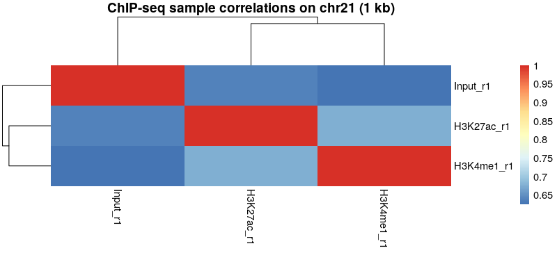

A few general points are worth keeping in mind when looking at this figure. The diagonal is always equal to `1`, because each sample is perfectly correlated with itself, while the off-diagonal cells summarise the similarity between different samples across all windows. Here we are using a simple exploratory approach: counts are summarised in `1-kb` bins, scaled to counts per million, log-transformed, and compared with Spearman correlation. This already gives a useful first impression of how similar the samples are, but it is still a lightweight summary rather than a full ChIP-seq quality-control analysis. The main goal is therefore to look for broad, biologically sensible patterns rather than to over-interpret small differences in colour or branch length. Because this analysis is restricted to `chr21`, includes only three samples, and does not use replicate averaging, the heatmap is best treated as an initial orientation step rather than a definitive biological result.

If we increase the bin size from `1 kb` to `10 kb`, we average the signal over larger genomic regions. This reduces local variation and tends to increase the apparent similarity between samples. The heatmap therefore becomes smoother and the correlations become higher, but we lose some fine-scale resolution.

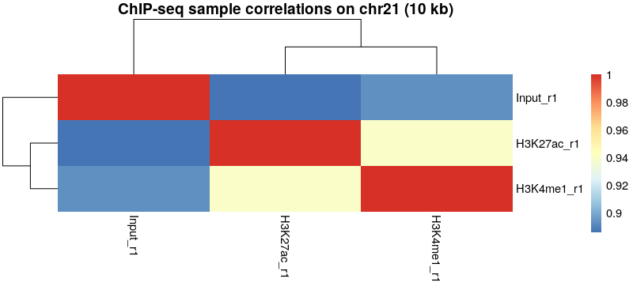

**NoteT2 Q1**

Do the two histone marks cluster more closely with each other or with the Input sample?

**NoteT2 Q2**

What does a high correlation between two ChIP samples mean biologically in this context?

**NoteT2 Q3**

Why do we normalise counts before comparing samples?

### Task 2 conclusion

At this stage, the correlation heatmap should be viewed as a **first exploratory sanity check**. Even with a simple workflow based on `chr21` only, the result is already informative: if the two histone-mark samples appear more similar to each other than to the Input sample, that is a reassuring sign that the ChIP-seq profiles contain structured biological signal beyond the background represented by the control.

At the same time, this is still a limited analysis. We have not yet carried out a full ChIP-seq quality-control workflow, and the result should therefore be interpreted with caution. In this task, the heatmap is useful mainly because it helps us check whether the data show a plausible overall pattern before moving on to more focused downstream analyses.

## Task 3: Trackorama - visualisation in a genome browser

It’s a good idea doing a direct visual inspection of the signal in a genome browser. Even when the statistics look acceptable, the browser can reveal:

- unexpected background,
- broad versus focal enrichment,
- suspicious local artefacts,
- agreement or disagreement between ChIP and Input.

`IGV` should already be familiar from **session 2**, when **Eszter Ari** introduced it in the context of next-generation sequencing, and from **session 7**, where it was used to inspect mapped RNA-seq reads. What we are going to change here is the interpretation: instead of looking for exon-aware alignment patterns, we will be looking for **enrichment profiles above Input background**.

For this exercise, use `IGV` or an equivalent browser and inspect:

- a known `chr21` gene locus such as `RUNX1`, and
- one additional region chosen by the teacher or by you.

Load:

1. the `GRCh38` gene annotation,
2. the `H3K27ac` signal track,
3. the `H3K4me1` signal track,
4. the `Input` `BAM` track.

For this practical, use `bigWig` files for the two histone marks and the `chr21` `BAM` file for the input sample. The input `bigWig` field is intentionally left empty in the manifest so that everyone uses the same browser setup, whether they followed the download route or the backup-copy route.

```bash
# Example only: open IGV from a normal terminal if available
igv.sh &
```

Alternatively, you may visualise selected loci using `Gviz` in `R`.

```r
library(Gviz)

h3k27ac_bw <- file.path("0002_bigwig", manifest$bigwig[manifest$sample_id == "H3K27ac_r1"])
h3k4me1_bw <- file.path("0002_bigwig", manifest$bigwig[manifest$sample_id == "H3K4me1_r1"])
input_bam  <- file.path("0001_bam", "Input_r1.chr21.bam")

axisTrack <- GenomeAxisTrack()

h3k27acTrack <- DataTrack(
  range = h3k27ac_bw,
  chromosome = "chr21",
  genome = "hg38",
  name = "H3K27ac",
  type = "histogram"
)

h3k4me1Track <- DataTrack(
  range = h3k4me1_bw,
  chromosome = "chr21",
  genome = "hg38",
  name = "H3K4me1",
  type = "histogram"
)

inputTrack <- AlignmentsTrack(
  range = input_bam,
  chromosome = "chr21",
  genome = "hg38",
  isPaired = FALSE,
  name = "Input"
)

plotTracks(
  list(axisTrack, h3k27acTrack, h3k4me1Track, inputTrack),
  chromosome = "chr21",
  from = 37000000,
  to = 37200000,
  sizes = c(0.6, 1.5, 1.5, 1.8)
)

png("0003_qc/Task3_Gviz_tracks_RUNX1.png", width = 1200, height = 900, res = 150)
plotTracks(
  list(axisTrack, h3k27acTrack, h3k4me1Track, inputTrack),
  chromosome = "chr21",
  from = 37000000,
  to = 37200000,
  sizes = c(0.6, 1.5, 1.5, 1.8)
)
dev.off()
```

For this task, we will focus on the gene `RUNX1`, because it is a transcription factor that regulates the differentiation of hematopoietic stem cells into mature blood cells. As a biologically relevant hematopoietic regulator on `chr21`, it is a sensible locus to inspect in K562 cells. This is also a useful adaptation of the original paper: there, the main genome-browser style example is the `SAR1B–SEC24A` locus on `chr5`, but in this practical we restrict ourselves to `chr21`, so `RUNX1` provides a good chromosome-21 alternative.

**Look for the coordinates of `RUNX1` (for example on ensembl.org), and replace the from/to parameters in the code, to plot a region of 30 kb around the promoter (take into account the direction of the gene).** [^5]

You should get something like this:

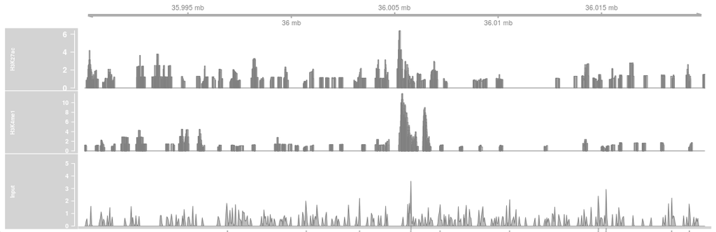

In this example, the two histone-mark tracks are shown together with the Input `BAM` track over a small promoter-centred region near `RUNX1` on `chr21`. The main point is not to measure exact signal values by eye, but to compare the overall shape of the profiles and to ask whether the ChIP signals rise above the background seen in the Input track. The Input track will often look rougher and less smooth than the `bigWig` tracks, because it is drawn directly from aligned reads rather than from a processed signal summary. As in the previous tasks, this is best treated as a qualitative browser view that helps interpretation, not as a formal statistical result.

**NoteT3 Q1**

At the locus you inspected, which mark looks more **broad**, and which looks more **focal**?

**NoteT3 Q2**

Where do you see convincing ChIP enrichment above Input background?

**NoteT3 Q3**

Why is visual inspection still useful even after you have produced quantitative plots?

## Task 4: Strandscape - plus/minus strand cross-correlation

In **session 3** (Genomics, Part 1), quality control mostly meant checking sequence-level or alignment-level properties. Here we move one level further: even if a file is already mapped and technically usable, we still need to ask whether the **immunoprecipitation created a meaningful enrichment pattern**, which is a specifically ChIP-seq way of thinking about QC.

A key common diagnostic is **plus/minus strand cross-correlation**. The idea is that a successful ChIP experiment should enrich DNA fragments of a characteristic length. If the reads on the plus and minus strands are shifted relative to one another by the fragment size, their cross-correlation profile should show a peak near that distance.

In ChIP-seq strand cross-correlation, the peaks are observed in a **cross-correlation profile**, not at specific genomic coordinates. The x-axis represents the **strand shift** (in base pairs), and the y-axis represents the **cross-correlation value** obtained after shifting the plus- and minus-strand coverage tracks relative to each other. Two peaks are often observed: one near the **read length** (the so-called **phantom peak**) and one near the **fragment length**. The phantom peak is a known short-read mappability artefact, whereas the fragment-length peak reflects the clustering of sequenced fragments around enriched regions. In a good enriched dataset, the **fragment-length peak should be higher than the phantom peak**, meaning that the cross-correlation value at the fragment-length shift is stronger than the read-length artefact (Landt et al. 2012; ENCODE Data Coordination Center 2020). By contrast, if the phantom peak is as high as or higher than the fragment-length peak, the signal is dominated by the read-length artefact rather than by the expected enrichment pattern, which is a warning sign of weak ChIP enrichment (and therefore, a low signal-to-noise ratio). A practical way to think about the two peaks is this: the phantom peak is expected near the **left-hand side** of the plot, at a small shift close to the read length, while the fragment-length peak is expected **further to the right**, at a larger shift corresponding to the average DNA fragment size.

The two diagrams below (Landt 2012) illustrate the idea. The first one shows the typical shapes of successful, marginal, and failed cross-correlation profiles, while the second highlights the expected positions of the **phantom peak** and the **ChIP/fragment-length peak**.

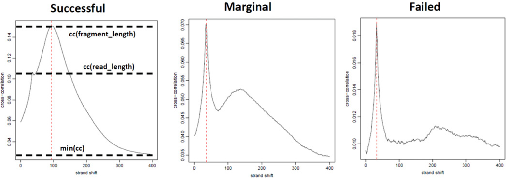

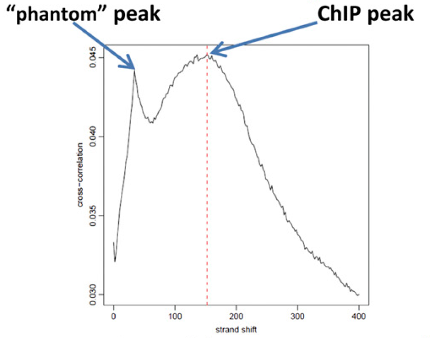

Taken together, these figures show why the fragment-length peak should dominate in a good ChIP-seq experiment: it reflects the expected clustering of reads around enriched fragments, whereas the phantom peak is a short-read artefact. If the phantom peak is higher, the profile looks more like a marginal or failed experiment than a successful one (Landt et al. 2012).

The **NSC** and **RSC** (Normalised and Relative Strand cross-correlation coefficients) are summary scores that compare the strength of the fragment-length peak with background and with the read-length phantom peak. They matter here because they help us judge whether the sample shows genuine ChIP enrichment rather than mostly technical artefact.

This is often calculated with `spp` or `phantompeakqualtools`, and it is one of the ENCODE-style ChIP quality diagnostics emphasised in the guidelines literature (Landt 2012). In this practical, we will use the shared `run_spp.R` script located at `/shared/software/phantompeakqualtools/run_spp.R`.

We can run it on the terminal from the folder where it has been downloaded for this course, asnd using the data for the H3K27ac:

```bash
Rscript /shared/software/phantompeakqualtools/run_spp.R \
  -c="~/09_ChIPseq/0001_bam/H3K27ac_r1.chr21.bam" \
  -odir="~/09_ChIPseq/0003_qc" \
  -savp="~/09_ChIPseq/0003_qc/Task4_H3K27ac_r1_crosscorr.pdf" \
  -out="~/09_ChIPseq/0003_qc/Task4_H3K27ac_r1_crosscorr.tsv"
```

Repeat the procedure for `H3K4me1` and `Input`. Then compare the console messages and the resulting `PDF` plots across the three samples.

If the shared installation under `/shared/software/phantompeakqualtools` is not available on your system, use the provided output files and the annotated example below for interpretation, then continue with the questions.

A typical successful run produces console output like the following:

```
################
ChIP data: ~/09_ChIPseq/0001_bam/H3K27ac_r1.chr21.bam
Control data: NA
strandshift(min): -500
strandshift(step): 5
strandshift(max) 1500
user-defined peak shift NA
exclusion(min): 10
exclusion(max): NaN
num parallel nodes: NA
FDR threshold: 0.01
NumPeaks Threshold: NA
Output Directory: ~/09_ChIPseq/0003_qc
narrowPeak output file name: NA
regionPeak output file name: NA
Rdata filename: NA
plot pdf filename: ~/09_ChIPseq/0003_qc/Task4_H3K27ac_r1_crosscorr.pdf
result filename: ~/09_ChIPseq/0003_qc/Task4_H3K27ac_r1_crosscorr.tsv
Overwrite files?: FALSE

[1] TRUE
Reading ChIP tagAlign/BAM file ~/09_ChIPseq/0001_bam/H3K27ac_r1.chr21.bam
opened /tmp/RtmpN3jEiX/H3K27ac_r1.chr21.tagAlignf641398e5fdf
done. read 138349 fragments
ChIP data read length 36
[1] TRUE
Calculating peak characteristics
Minimum cross-correlation value 0.1436713
Minimum cross-correlation shift 1500
Top 3 cross-correlation values 0.289388842986033,0.288587962636664
Top 3 estimates for fragment length 170,180
Window half size 615
Phantom peak location 40
Phantom peak Correlation 0.2335835
Normalized Strand cross-correlation coefficient (NSC) 2.014242
Relative Strand cross-correlation Coefficient (RSC) 1.620665
Phantom Peak Quality Tag 2
null device
          1
```

How to read this output:

- The first block mainly confirms **which input file** was used and **where the results were written**. This is useful to check that the script is analysing the correct `BAM` file and saving the `PDF` and `TSV` files in the expected directory.
- The line `done. read 138349 fragments` tells us that the program successfully read the `chr21`-restricted `BAM` file and extracted enough mapped fragments to compute a cross-correlation profile. This count is a little below what one would expect by extrapolating whole-genome depth recommendations to chr21, but it stays within the expected order of magnitude.[^6]
- The line `ChIP data read length 36` tells us where the short-shift phantom peak is expected: in this example, around `35–40 bp`.
- The line `Top 3 estimates for fragment length 170,180` is one of the most important results. It suggests that the enriched DNA fragments in this sample are roughly in that size range, which is biologically plausible for a ChIP-seq library.
- The line `Phantom peak location 40` means that the short-shift read-length artefact is strongest at a strand shift of about 40 bp. Since this dataset has a read length of 36 bp, that is where a phantom peak is expected.
- The lines `NSC` and `RSC` are the main summary quality measures. Here, both values are higher than 1, which is encouraging, as it suggests that the signal in the sample is much higher than the background noise.
- The final line `null device 1` simply shows that the plot file was written and the graphics device was closed normally.

The cross-correlation profile captures a good fragment-length-related signal, and the summary metrics are consistent with a successful ChIP enrichment. In particular, the fragment-length signal is stronger than the short-shift phantom peak, which is the pattern we want to see. At the same time, the plot is not expected to be “beautiful” in a polished publication sense: here we are working with a `chr21`-restricted file, so the result should be treated as an instructive and biologically sensible QC example rather than as a full genome-wide benchmark.

**NoteT4 Q1**

Open the pdf for the three results (the two histone marks and the Input), which contains the plus/minus strand cross-correlation plot for our ChIP-seq dataset, and comment about the quality of the experiment in each case.

**NoteT4 Q2**

Why would an Input sample usually be less informative in this diagnostic than a successful ChIP sample?

**NoteT4 Q3**

What does a fragment-length-related peak suggest about the success of the ChIP enrichment?

## Task 5: GCBloom - visualising GC bias

Sometimes datasets present technical biases due to amplification, library preparation, or sequencing chemistry. To detect them, it is often recommended in ChIP-seq analysis to plot the relationship between GC content and signal abundance (number of reads aligned) across genomic bins. One reason is that some sequencers coverage can depend on the overall GC composition of the sequenced fragment, so bins with very low or very high GC content may end up over- or under-represented even when their true biological enrichment is similar. Another reason is that PCR can amplify fragments of different base composition with unequal efficiency, which can distort coverage independently of the real ChIP signal. A common way to reduce this problem is to model the dependence of coverage on GC content and then normalise or correct the signal before downstream comparison, although this would be beyond the goals of this practical.

Here we will combine the `1-kb` windows from Task 2 with the `GRCh38` sequence of `chr21`, and we will first inspect the `H3K27ac_r1` sample as a simple example before comparing it with the other two samples.

We start by loading the libraries that will be used:

```r
library(BSgenome.Hsapiens.UCSC.hg38)
library(ggplot2)
```

We get sequences for the bins:

```r
seqs <- getSeq(BSgenome.Hsapiens.UCSC.hg38, bins)
```

We approximate the GC fraction of each 1-kb bin:

```r
base_counts <- letterFrequency(seqs, letters = c("G", "C"))
gc_fraction <- rowSums(base_counts) / width(seqs)

gc_df <- data.frame(
  GC = gc_fraction,
  cpm = cpm[, "H3K27ac_r1"]
)
```

Plotting it:

```r
ggplot(gc_df, aes(x = GC, y = log10(cpm + 1))) +
  geom_point(alpha = 0.05, size = 0.5) +
  theme_bw() +
  xlab("GC content in 1-kb bins") +
  ylab("log10(CPM + 1)") +
  ggtitle("H3K27ac_r1")

ggsave("0003_qc/Task5_gc_bias_H3K27ac_r1.png", width = 5, height = 4)
```

The figure below shows the relationship between `GC` content and signal abundance for the `H3K27ac_r1` sample across `1-kb` bins on `chr21`. Each point represents one genomic bin. The x-axis shows the **GC fraction** of the bin, that is, the proportion of bases in that `1-kb` window that are either `G` or `C`. The y-axis shows **log10(CPM + 1)**, where `CPM` means *counts per million* (the number of mapped ChIP-seq reads or fragments overlapping that `1-kb` window).

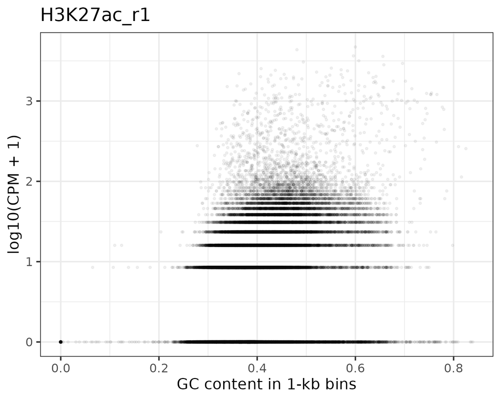

Our goal is to look at the overall shape of the cloud. In particular, ask whether signal values appear roughly spread across the GC range or whether they seem to increase systematically in bins with higher GC content. This will help you decide whether a strong GC-dependent bias is obvious in this sample. If there were no GC bias, bins with different GC content would not show a systematic difference in signal abundance. In other words, the number of mapped reads per bin should not consistently increase or decrease only because the bin is more GC-rich or more AT-rich.[^7]

Now modify the code to generate equivalent plots for `H3K4me1_r1` and `Input_r1`. Don’t forget to update the titles, so you don’t overwrite the files.

Once you have generated all three plots, compare them side by side. A useful question is whether the two histone-mark samples show a broadly similar pattern to each other, and whether the Input sample looks different in overall spread or shape across the GC range. This will help us to decide whether one sample appears more GC-dependent than the others, which in an experiment with many samples can be of interest.

**NoteT5 Q1**

Do the ChIP and Input samples show similar or different GC-dependent behaviour?

**NoteT5 Q2**

What kind of plot shape would make you suspect a strong technical bias?

**NoteT5 Q3**

Why is it useful to compare GC-bias patterns **between** samples, and not only within one sample?

## Task 6: Genomaplex - genomic distribution of reads or windows

One useful ChIP-seq quality-control view is the **genomic distribution** of signal across functional categories. If a ChIP sample looks too similar to the `Input` sample in this summary, that is a warning sign that the experiment may not show strong biological enrichment. Here we will follow the same logic, but instead of relying on pre-made `BED` files we will build the annotation directly in `R` from Bioconductor and then export the resulting `BED` files into `0005_annotation/` for reuse later in the practical.[^8]

This task has four goals:

1. create `chr21` annotation categories locally from a transcript database,
2. export those categories as `BED` files,
3. assign each `1-kb` bin from Task 2 to one category using a hierarchy,
4. compare how the total ChIP signal is distributed across categories.

For `H3K27ac` and `H3K4me1`, we expect more signal in promoter-proximal or distal regulatory bins than in the `Input` sample (Heintzman 2009; Creyghton 2010; Landt 2012). Because genomic features can overlap, we will use a simple hierarchy:

`tss` > `exon` > `intron` > `distal_regulatory` > `intergenic`

Here, `tss` means ±`1 kb` around the transcription start site. For teaching purposes, we will define `distal_regulatory` as regions within `50 kb` of a `TSS` but outside the `tss`, `exon`, and `intron` categories. This is only a working approximation of distal regulatory space, not a universal biological definition.

If you restarted `RStudio` since Task 2, the code below will load the libraries and recreate the `bins` and `cpm` objects automatically before doing the annotation.

```r
library(GenomicRanges)
library(GenomicAlignments)
library(GenomicFeatures)
library(TxDb.Hsapiens.UCSC.hg38.knownGene)
library(rtracklayer)
library(dplyr)
library(tidyr)
library(ggplot2)

manifest <- read.delim("0000_metadata/encode_k562_manifest.tsv", stringsAsFactors = FALSE)

if (!exists("bins") || !exists("cpm")) {
  chr21_length <- 46709983

  bins <- tileGenome(
    seqlengths = c(chr21 = chr21_length),
    tilewidth = 1000,
    cut.last.tile.in.chrom = TRUE
  )

  bam_files <- file.path("0001_bam", paste0(manifest$sample_id, ".chr21.bam"))
  names(bam_files) <- manifest$sample_id

  se <- summarizeOverlaps(
    features = bins,
    reads = bam_files,
    mode = "Union",
    singleEnd = TRUE,
    ignore.strand = TRUE
  )

  counts <- assay(se)
  cpm <- t(t(counts) / colSums(counts) * 1e6)
}

chr21_length <- 46709983
```

Build chr21 gene, exon, intron, and promoter annotations from the TxDb database:

```r
chr21_range  <- GRanges("chr21", IRanges(1, chr21_length))

txdb <- TxDb.Hsapiens.UCSC.hg38.knownGene

genes_chr21 <- genes(txdb)
genes_chr21 <- keepSeqlevels(genes_chr21, "chr21", pruning.mode = "coarse")

exons_chr21 <- exons(txdb)
exons_chr21 <- keepSeqlevels(exons_chr21, "chr21", pruning.mode = "coarse")
exons_chr21 <- reduce(exons_chr21)

introns_chr21 <- unlist(intronsByTranscript(txdb), use.names = FALSE)
introns_chr21 <- keepSeqlevels(introns_chr21, "chr21", pruning.mode = "coarse")
introns_chr21 <- reduce(introns_chr21)

tss_chr21 <- promoters(genes_chr21, upstream = 1000, downstream = 1000)
tss_chr21 <- reduce(tss_chr21)

tss_50kb_chr21 <- promoters(genes_chr21, upstream = 50000, downstream = 50000)
tss_50kb_chr21 <- reduce(tss_50kb_chr21)
```

Define distal-regulatory and intergenic regions after removing promoter and gene-body overlaps:

```r
distal_regulatory_chr21 <- GenomicRanges::setdiff(
  tss_50kb_chr21,
  reduce(c(tss_chr21, exons_chr21, introns_chr21))
)

intergenic_chr21 <- GenomicRanges::setdiff(
  chr21_range,
  reduce(c(tss_chr21, exons_chr21, introns_chr21, distal_regulatory_chr21))
)
```

Export annotation BED files in bedtools-compatible coordinate order, and assign each 1-kb bin to one genomic category:

```r
dir.create("0005_annotation", showWarnings = FALSE)

export_bed_chr21 <- function(gr, file) {
  gr <- gr[order(start(gr), end(gr))]
  export(gr, file, format = "BED")
}

export_bed_chr21(genes_chr21,             "0005_annotation/chr21_genes.bed")
export_bed_chr21(tss_chr21,               "0005_annotation/chr21_tss.bed")
export_bed_chr21(exons_chr21,             "0005_annotation/chr21_exon.bed")
export_bed_chr21(introns_chr21,           "0005_annotation/chr21_intron.bed")
export_bed_chr21(distal_regulatory_chr21, "0005_annotation/chr21_distal_regulatory.bed")
export_bed_chr21(intergenic_chr21,        "0005_annotation/chr21_intergenic.bed")
export_bed_chr21(bins,                    "0005_annotation/chr21_1kb_bins.bed")

bin_category <- rep("intergenic", length(bins))
bin_category[countOverlaps(bins, distal_regulatory_chr21) > 0] <- "distal_regulatory"
bin_category[countOverlaps(bins, introns_chr21) > 0] <- "intron"
bin_category[countOverlaps(bins, exons_chr21) > 0] <- "exon"
bin_category[countOverlaps(bins, tss_chr21) > 0] <- "tss"

bin_annotation <- data.frame(
  bin_id = seq_along(bins),
  category = factor(
    bin_category,
    levels = c("tss", "exon", "intron", "distal_regulatory", "intergenic")
  )
)
```

Save the bin-level genomic category table for later inspection and reuse:

```r
write.table(
  bin_annotation,
  file = "0006_results/Task6_bin_annotation_chr21.tsv",
  sep = "\t",
  quote = FALSE,
  row.names = FALSE
)
```

Combine CPM values with annotation and summarise signal by genomic category:

```r
signal_df <- as.data.frame(cpm)
signal_df$bin_id <- seq_len(nrow(signal_df))

signal_long <- signal_df %>%
  left_join(bin_annotation, by = "bin_id") %>%
  pivot_longer(
    cols = all_of(manifest$sample_id),
    names_to = "sample_id",
    values_to = "cpm"
  ) %>%
  group_by(sample_id, category) %>%
  summarise(
    total_cpm = sum(cpm),
    mean_cpm = mean(cpm),
    n_bins = n(),
    .groups = "drop"
  ) %>%
  group_by(sample_id) %>%
  mutate(percent_signal = 100 * total_cpm / sum(total_cpm)) %>%
  ungroup()
```

Write the per-sample signal summary table to the results folder:

```r
write.table(
  signal_long,
  file = "0006_results/Task6_signal_by_category_chr21.tsv",
  sep = "\t",
  quote = FALSE,
  row.names = FALSE
)
```

Plot the genomic signal distribution and save the figure for interpretation:

```r
signal_long_plot <- signal_long %>%
  mutate(
    sample_label = recode(
      sample_id,
      H3K27ac_r1 = "H3K27ac",
      H3K4me1_r1 = "H3K4me1",
      Input_r1   = "Input"
    ),
    category = factor(
      category,
      levels = c("intergenic", "distal_regulatory", "intron", "exon", "tss"),
      labels = c("Intergenic", "Distal regulatory", "Intron", "Exon", "TSS")
    )
  )

p_task6 <- ggplot(signal_long_plot, aes(x = sample_label, y = percent_signal, fill = category)) +
  geom_col(width = 0.85, colour = "white", linewidth = 0.2) +
  scale_y_continuous(
    limits = c(0, 100),
    breaks = seq(0, 100, by = 20),
    expand = c(0, 0)
  ) +
  scale_fill_brewer(palette = "Set2", name = "Genomic category") +
  labs(
    title = "Genomic distribution of chr21 signal",
    subtitle = "Percentage of total CPM assigned to each annotation category",
    x = "Sample",
    y = "Percentage of total CPM"
  ) +
  theme_classic(base_size = 12) +
  theme(
    plot.title = element_text(face = "bold", hjust = 0.5),
    plot.subtitle = element_text(hjust = 0.5),
    axis.title = element_text(face = "bold"),
    axis.text.x = element_text(angle = 35, hjust = 1),
    legend.position = "right",
    legend.title = element_text(face = "bold")
  )

p_task6

ggsave(
  "0006_results/Task6_genomic_distribution_signal_chr21.png",
  plot = p_task6,
  width = 7.2,
  height = 4.8,
  dpi = 300
)
```

The first thing to check after running this code is whether the `0005_annotation/` folder now contains the exported `BED` files. These files were created from the Bioconductor annotation and can be reused later for `bedtools` or for ad hoc inspection. They are exported in coordinate order so that they can be reused directly by `bedtools` in later tasks without additional re-sorting.

The expected output is the figure below. It summarises how the signal from each sample is distributed across `tss` (Transcription Start Site), `exon`, `intron`, `distal_regulatory`, and `intergenic` bins on `chr21`.

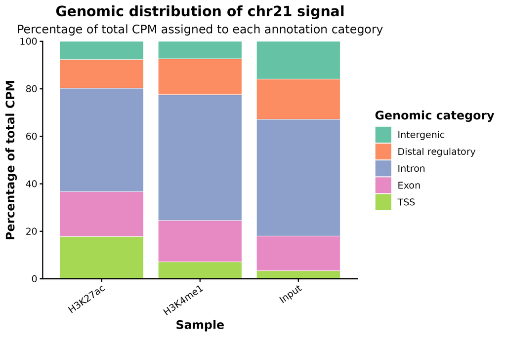

This plot should be interpreted as a coarse quality-control summary rather than as a definitive biological annotation. In this dataset, `H3K27ac` shows the clearest relative enrichment in `tss` bins, whereas the `Input` sample has the largest relative contribution from `distal_regulatory` and `intergenic` bins. That does **not** mean that `Input` is specifically marking enhancers. A more cautious interpretation is that the `Input` control is not a flat background and may retain biases related to chromatin accessibility, fragmentation, and other non-specific signal; in addition, the `distal_regulatory` class used here is a broad proximity-based proxy rather than a validated enhancer catalogue (Park 2009; Landt 2012; Xu 2021). Relative to `Input`, `H3K27ac` still behaves more like an active regulatory mark, whereas `H3K4me1` appears closer to `Input` in this summary, which is compatible with the broader and sometimes poised enhancer-associated nature of `H3K4me1` compared with `H3K27ac` (Heintzman 2009; Creyghton 2010; Calo 2013).

Pay special attention to the `distal_regulatory` category. In this practical definition, these are non-exonic, non-intronic, non-promoter regions within `50 kb` of a gene start site. They are not guaranteed to be true enhancers, and they may include a mixture of bona fide enhancers, other nearby accessible regions, and unclassified regulatory DNA. For that reason, this category is best treated as a first-pass proxy for “enhancer-like / near-regulatory space”, not as a definitive enhancer annotation.

**NoteT6 Q1**

Which genomic categories are relatively enriched in the two histone-mark samples compared with the `Input` sample, and which histone mark looks most different from `Input`?

**NoteT6 Q2**

In this dataset, the `Input` sample shows the largest relative contribution from `distal_regulatory` bins on `chr21`. Give two plausible explanations for this pattern, and explain why `H3K4me1` may still be biologically consistent with enhancer-like chromatin even though it looks closer to `Input` than `H3K27ac` in this coarse summary.

**NoteT6 Q3**

Why is a hierarchical annotation useful when a `1-kb` bin overlaps more than one genomic feature, and what ambiguity would arise if the same bin were counted in all overlapping categories?

# Peak calling and downstream interpretation

After quality control, we will proceed to **peak calling**, followed by **peak quality control** and **peak annotation**. The reference book uses `normR`, which is very useful for teaching the logic of enrichment modelling. In this practical, however, we will use `MACS2` in `--broad` mode (Zhang 2008)[^9] because:

- it is commonly used in practice,
- it is straightforward in a workshop setting,
- it matches the broad nature of histone-mark enrichment reasonably well.

We will still interpret the output using the same conceptual framework as Chapter 9. In addition, after Tasks 7 and 8 we will add one final integrative step: we will use `ChromHMM` to binarise the two histone-mark BAM files against Input, learn a small chromatin-state model on `chr21`, and ask whether the peak-derived candidate regulatory regions are supported by the learned segmentation. This is not part of the chapter’s core peak-calling walkthrough, but it fits naturally with the downstream integration and genome-segmentation ideas mentioned later in Chapter 9.

There is also a nice continuity here with the genomics block: in **session 3** (Genomics, Part 1), `BAM` files were the endpoint of raw-read processing, and in **session 4** (Genomics, Part 2), `samtools` reappeared as part of downstream variant analysis. In today’s practical, the same kind of alignment files become the starting material for a different downstream question: not sequence variation, but chromatin enrichment and regulatory state.

## Task 7: Peaksmith - peak calling and peak quality control

In this task, we turn aligned ChIP-seq reads into candidate enriched regions and then ask whether those peak sets are coherent enough to use downstream. This task has two parts:

1. call broad peaks for each histone mark against the matched `Input` control,
2. assess whether those peak sets capture a meaningful fraction of the ChIP signal and remain enriched relative to `Input`.

These quality-control summaries are **not** the final biological result of the practical. Their purpose is to decide whether the peak sets are reliable enough to carry forward into **Task 8**, where overlapping `H3K4me1` + `H3K27ac` regions will be treated as candidate active regulatory loci, into **Task 9**, where a simple `ChromHMM` segmentation will test whether that interpretation is supported at the chromatin-state level, and finally into **Task 10**, where the result will be visualised along `chr21`.

### Task 7.1: Broad peak calling for histone marks

Histone marks are not all alike. They can have **sharp**, **broad**, and **mixed** signal profiles. Our two marks are histone modifications associated with regulatory regions, and `H3K4me1` in particular often produces relatively broad enrichment domains.

We will therefore call peaks using `MACS2` with broad-peak settings.

Given the goals and time limits of this practical, we will focus here on peak definition and immediate quality assessment. In a longer workshop with additional histone marks, replicates, cell types, or conditions, one natural extension would be differential peak calling.

Call broad peaks for the H3K27ac sample against the shared Input control.

```bash
macs2 callpeak \
  -t 0001_bam/H3K27ac_r1.chr21.bam \
  -c 0001_bam/Input_r1.chr21.bam \
  -f BAM \
  -g 4.67e7 \
  -n H3K27ac_r1_chr21 \
  --broad \
  --broad-cutoff 0.1 \
  --outdir 0004_peaks
```

Same for H3K4me1:

```bash
macs2 callpeak \
  -t 0001_bam/H3K4me1_r1.chr21.bam \
  -c 0001_bam/Input_r1.chr21.bam \
  -f BAM \
  -g 4.67e7 \
  -n H3K4me1_r1_chr21 \
  --broad \
  --broad-cutoff 0.1 \
  --outdir 0004_peaks
```

In this practical, keep `-f BAM`: the staged `chr21` files are single-end `BAM` files.

In this practical, keep `-g 4.67e7`, because peak calling is being performed on `chr21`-restricted `BAM` files and we use the size of `chr21` as a classroom approximation for the effective genome size.

For the rest of this task, focus mainly on the `*.broadPeak` files, because those are the peak files that will be carried forward into the downstream steps.

Typical output files include:

- `*.broadPeak`
- `*.gappedPeak`
- model or log files

A successful `MACS2` run should end with output similar to the excerpt below:

```
# format = BAM
# effective genome size = 4.67e+07
# Broad region calling is on
# Paired-End mode is off
#2 predicted fragment length is 185 bps
#4 Write broad peak in broadPeak format file... 0004_peaks/H3K27ac_r1_chr21_peaks.broadPeak
#4 Write broad peak in bed12/gappedPeak format file... 0004_peaks/H3K27ac_r1_chr21_peaks.gappedPeak
INFO  ... Done!
```

In this practical, the most important points are that `MACS2` recognises the files as **single-end** (`Paired-End mode is off`), uses the `chr21` effective genome size that we supplied, successfully infers a fragment length, and writes the expected `broadPeak` and `gappedPeak` files. The exact read counts, fragment length, and peak totals may vary slightly with software version or preprocessing, but the overall structure of the log should look like this.

Before answering the questions, inspect the peak files directly. First, look at the first few lines so that you can see what a `broadPeak` file looks like; then compare how many regions were called for each mark and how wide those regions are on average.

Your output should be similar to the examples shown below, although exact values can differ slightly depending on software version and upstream preprocessing.

Look at the first few called broad peaks

```bash
head 0004_peaks/H3K27ac_r1_chr21_peaks.broadPeak
head 0004_peaks/H3K4me1_r1_chr21_peaks.broadPeak
```

Example output from this dataset:

```
chr21   5065383 5065716 H3K27ac_r1_chr21_peak_1 15      .       3.24873 3.6126  1.57438
chr21   5128275 5128511 H3K27ac_r1_chr21_peak_2 47      .       5.17999 6.98643 4.73634
chr21   5240725 5241143 H3K27ac_r1_chr21_peak_3 63      .       5.62155 8.6902  6.3703

[...]
```

These rows show that a `broadPeak` file is still basically a genomic interval table. The first three columns are the chromosome, start, and end coordinates; the fourth column is the peak name assigned by `MACS2`. The later columns contain a score and enrichment statistics. At this stage, students do not need to memorise every column, but they should recognise that each line represents one called broad peak with both genomic coordinates and a measure of confidence.

Summarise the number and mean width of called broad peaks

```bash
for f in 0004_peaks/H3K27ac_r1_chr21_peaks.broadPeak 0004_peaks/H3K4me1_r1_chr21_peaks.broadPeak; do
  awk 'BEGIN{n=0;sum=0}
       {w=$3-$2; sum+=w; n++}
       END{
         if(n>0){
           printf "%s\tpeaks=%d\tmean_width=%.1f bp\n", FILENAME, n, sum/n
         } else {
           printf "%s\tpeaks=0\tmean_width=NA\n", FILENAME
         }
       }' "$f"
done
```

Example output from this dataset:

```
0004_peaks/H3K27ac_r1_chr21_peaks.broadPeak     peaks=662       mean_width=710.7 bp
0004_peaks/H3K4me1_r1_chr21_peaks.broadPeak     peaks=1607      mean_width=614.1 bp
```

In this particular run, `H3K4me1` produces **more** called broad peaks on `chr21`, but `H3K27ac` has the **larger mean peak width**. That is a useful reminder that “more peaks” and “broader peaks” are not the same thing. Because this analysis is being run on a `chr21` subset with a specific `MACS2` broad-peak setting, the exact numbers should not be over-generalised; what matters more is that the two histone marks do not produce identical peak landscapes, which is biologically reasonable for marks with related but distinct regulatory associations (Heintzman 2009; Creyghton 2010; Calo 2013).

Inspect the five broadest called regions for each mark

```bash
for f in 0004_peaks/H3K27ac_r1_chr21_peaks.broadPeak 0004_peaks/H3K4me1_r1_chr21_peaks.broadPeak; do
  echo "### $f"
  awk 'BEGIN{OFS="\t"} {print $1, $2, $3, $3-$2}' "$f" | sort -k4,4nr | sed -n '1,5p'
done
```

Example output from this dataset:

```
### 0004_peaks/H3K27ac_r1_chr21_peaks.broadPeak
chr21   34906171        34910344        4173
chr21   31734458        31738607        4149
chr21   35025666        35029657        3991
chr21   14451569        14455457        3888
chr21   46320030        46323890        3860

### 0004_peaks/H3K4me1_r1_chr21_peaks.broadPeak
chr21   14450597        14455911        5314
chr21   39315374        39320548        5174
chr21   29639150        29644189        5039
chr21   42543810        42548415        4605
chr21   38850282        38854303        4021
```

These results are interesting because they show that `H3K4me1` contains some of the **widest individual peaks** in the dataset, even though its **mean peak width** is smaller than that of `H3K27ac`. In other words, the extreme tail of the width distribution and the average width can tell slightly different stories. This is exactly why it is worth looking at both a summary statistic and a few concrete examples rather than relying on a single number.

**NoteT7 Q1**

Using the summary command above, which mark produces **more** called broad-peak regions on `chr21`, and how many regions were called for each sample?

**NoteT7 Q2**

Using the width summary above, which mark has the **larger mean peak width** in this dataset? Does that agree with the list of the **five broadest individual peaks**, and what does that tell you about the difference between an average and the extreme tail of a distribution?

**NoteT7 Q3**

Why is it important to compare each ChIP sample against `Input` during peak calling, and why should the `Input` sample still not be assumed to be perfectly flat across the chromosome?

### Task 7.2: Peak quality control - percentage of reads in peaks

A good way to test whether the called peaks truly capture a substantial proportion of the ChIP signal is by checking the **percentage of reads in peaks**. FRiP-style summaries are part of standard ChIP-seq quality assessment practice (Landt 2012).

A simplified FRiP-like summary[^10] can be computed by combining `samtools` (Li 2009) and `bedtools` (Quinlan and Hall 2010): count how many aligned reads overlap the called peaks and divide by the total number of mapped reads.

Build a simplified FRiP-like summary for both histone-mark samples. First create the output file and write its header:

```bash
printf "sample\ttotal_reads\treads_in_peaks\tpercent_reads_in_peaks\n" > 0006_results/Task7_FRiP_like_summary.tsv
```

Count mapped reads, sum reads overlapping peaks, and calculate the FRiP-like percentage.

```bash
for mark in H3K27ac H3K4me1; do
  total=$(samtools view -c -F 4 0001_bam/${mark}_r1.chr21.bam)

  bedtools coverage -counts \
    -a 0004_peaks/${mark}_r1_chr21_peaks.broadPeak \
    -b 0001_bam/${mark}_r1.chr21.bam \
    > 0006_results/${mark}_peak_read_counts.tsv

  inpeaks=$(awk '{sum += $NF} END{print sum+0}' 0006_results/${mark}_peak_read_counts.tsv)
  pct=$(awk -v a="$inpeaks" -v b="$total" 'BEGIN{printf "%.2f", 100*a/b}')

  printf "%s\t%s\t%s\t%s\n" "$mark" "$total" "$inpeaks" "$pct" >> 0006_results/Task7_FRiP_like_summary.tsv
done
```

Display the summary table in a readable format.

```bash
column -t 0006_results/Task7_FRiP_like_summary.tsv
```

Example output from this dataset:

```
sample   total_reads  reads_in_peaks  percent_reads_in_peaks
H3K27ac  138349       52412           37.88
H3K4me1  123943       50828           41.01
```

The files `H3K27ac_peak_read_counts.tsv` and `H3K4me1_peak_read_counts.tsv` are **intermediate tables**, not the final percentage by themselves. Each row corresponds to one called peak, and the **last column** reports how many aligned reads overlap that peak. To obtain the simplified FRiP-like value, sum the last column and divide by the total number of mapped reads for that sample.

In this practical, these values should be interpreted **comparatively**, not as strict pass/fail thresholds, because they are computed on `chr21`-restricted files and broad peak sets rather than on full-genome peak calls. The main point is that the two histone marks are not identical: `H3K4me1` appears to distribute reads across more peak regions, while `H3K27ac` appears to concentrate signal in fewer but broader domains. That is broadly compatible with the known biology of these marks, while still remaining a coarse classroom-scale summary (Heintzman 2009; Creyghton 2010; Calo 2013; Landt 2012).

A higher FRiP-like percentage means that a larger fraction of reads falls inside the called peaks, which is usually consistent with stronger enrichment and better signal-to-noise (Landt 2012). In this dataset, both histone-mark samples place a substantial fraction of their `chr21` reads inside their own called broad peaks: `37.88%` for `H3K27ac` and `41.01%` for `H3K4me1`. The main practical meaning of this result is that both peak sets look coherent enough to carry forward into downstream interpretation, rather than being obviously too diffuse or too weak to use.

The slightly higher FRiP-like value for `H3K4me1` means that, with these `MACS2` settings on `chr21`, a somewhat larger fraction of `H3K4me1` reads is captured by its own peak set. That does **not** by itself mean that `H3K4me1` is biologically “stronger” or more important than `H3K27ac`. FRiP-like summaries are quality-control measures, not direct functional annotations. They should therefore be interpreted together with the browser-style inspection, the peak-count summary, the peak-width summary, and the comparison to `Input` (Landt 2012).

To examine the `Input` sample properly, do not call a separate FRiP from an `Input` peak set. Instead, reuse the already called `H3K27ac` and `H3K4me1` peak regions as the reference intervals, and ask how many `Input` reads fall inside those same regions. This is the decisive control comparison for Task 7.2, because these are exactly the peak sets that we would like to treat as candidate regulatory regions in Task 8.

Count `Input` reads inside each histone-mark peak set

```bash
printf "peak_set\tinput_total_reads\tinput_reads_in_peaks\tinput_percent_in_peaks\n" > 0006_results/Task7_Input_in_histone_peaks.tsv

input_total=$(samtools view -c -F 4 0001_bam/Input_r1.chr21.bam)

for mark in H3K27ac H3K4me1; do
  bedtools coverage -counts \
    -a 0004_peaks/${mark}_r1_chr21_peaks.broadPeak \
    -b 0001_bam/Input_r1.chr21.bam \
    > 0006_results/Input_in_${mark}_peaks.tsv

  input_in_peaks=$(awk '{sum += $NF} END{print sum+0}' 0006_results/Input_in_${mark}_peaks.tsv)
  input_pct=$(awk -v a="$input_in_peaks" -v b="$input_total" 'BEGIN{printf "%.2f", 100*a/b}')

  printf "%s\t%s\t%s\t%s\n" "$mark" "$input_total" "$input_in_peaks" "$input_pct" >> 0006_results/Task7_Input_in_histone_peaks.tsv
done

column -t 0006_results/Task7_Input_in_histone_peaks.tsv
```

If the `Input` sample also shows substantial read accumulation inside the histone-mark peak regions, that suggests that some of the apparent ChIP enrichment may reflect background structure, local accessibility, or other non-specific biases rather than strongly mark-specific signal. If, on the other hand, the `Input` percentages are clearly lower than the corresponding ChIP percentages, then the peak sets have passed an important quality-control checkpoint and can be carried forward with more confidence into Task 8. The key question here is therefore not “is the number high or low in absolute terms?”, but rather “does the ChIP sample concentrate reads in these regions more strongly than the matched control?” (Landt 2012).

**NoteT7 Q4**

Which histone mark has the higher simplified FRiP-like percentage on `chr21`? Based on this result together with the peak-count and peak-width summaries, would you keep both peak sets for downstream interpretation in Task 8, or would you already be concerned about one of them?

**NoteT7 Q5**

After counting `Input` reads inside the `H3K27ac` and `H3K4me1` peak regions, do the control percentages look clearly lower than the corresponding ChIP percentages? Based on that comparison, is it justified to carry these peak sets forward into Task 8 as candidate regulatory regions?

## Task 8: Enhansemble - intersecting peaks and annotating candidate active regulatory regions

We will now combine both histone marks. Regions enriched for both `H3K4me1` and `H3K27ac` are often interpreted as stronger candidates for **active enhancer-like regions** than regions marked by only one of them, because `H3K4me1` marks enhancer-like elements and `H3K27ac` is associated with active enhancer activity (Heintzman 2009; Creyghton 2010).

These overlap-derived regions will then be carried forward into **Task 9**, where we will binarise the histone ChIP-seq data, learn a small `ChromHMM` model on `chr21`, and ask whether the resulting chromatin states support the enhancer-like interpretation suggested by the peak overlap. In **Task 10**, we will then visualise those same regions together with the learned state segmentation along the chromosome.

Intersect the peak sets:

```bash
bedtools intersect \
  -u \
  -a 0004_peaks/H3K27ac_r1_chr21_peaks.broadPeak \
  -b 0004_peaks/H3K4me1_r1_chr21_peaks.broadPeak \
  > 0006_results/H3K27ac_H3K4me1_overlap_chr21.bed
```

We have preinstalled `Homer` in the workstation for the course. We can use it to **annotate the overlapping regions**:

```bash
annotatePeaks.pl \
  0006_results/H3K27ac_H3K4me1_overlap_chr21.bed hg38 \
  > 0006_results/H3K27ac_H3K4me1_overlap_annotated.txt
```

However, sometimes `Homer` might not be available. If this is the case, use `bedtools closest` with the `chr21_genes.bed` file exported in Task 6, which was already written in bedtools-compatible coordinate order. This fallback gives one row per overlapping peak region together with the nearest annotated gene:

```bash
bedtools closest \
  -a 0006_results/H3K27ac_H3K4me1_overlap_chr21.bed \
  -b 0005_annotation/chr21_genes.bed \
  > 0006_results/H3K27ac_H3K4me1_overlap_nearest_gene.tsv
```

Summarise the overlap and inspect the nearest-gene table in R:

```r
overlap <- read.delim(
  "0006_results/H3K27ac_H3K4me1_overlap_nearest_gene.tsv",
  header = FALSE,
  stringsAsFactors = FALSE
)

nrow(overlap)
head(overlap)
```

Example output from this dataset:

```
[1] 599

     V1      V2      V3                       V4  V5 V6       V7       V8       V9   V10     V11
1 chr21 5240725 5241143  H3K27ac_r1_chr21_peak_3  63  .  5.62155  8.69020  6.37030 chr21 5155498
2 chr21 5242767 5244538  H3K27ac_r1_chr21_peak_5 176  .  8.98242 20.22390 17.69190 chr21 5155498
3 chr21 5244704 5245392  H3K27ac_r1_chr21_peak_6  85  .  6.06519 10.88410  8.52889 chr21 5155498
4 chr21 5246097 5246865  H3K27ac_r1_chr21_peak_7  75  .  5.56117  9.83317  7.50834 chr21 5155498
5 chr21 9766842 9768469 H3K27ac_r1_chr21_peak_13 250  . 12.33330 27.67400 25.01610 chr21 9781909
6 chr21 9823386 9823748 H3K27ac_r1_chr21_peak_14  49  .  4.80228  7.16511  4.93889 chr21 9781909
      V12       V13 V14 V15
1 5163695 102724200   0   -
2 5163695 102724200   0   -
3 5163695 102724200   0   -
4 5163695 102724200   0   -
5 9816833    441058   0   -
6 9816833    441058   0   -
```

In this dataset, `nrow(overlap) = 599` means that `599` `H3K27ac` peaks on `chr21` also overlap an `H3K4me1` peak, so these regions are our first-pass set of candidate active regulatory loci. In the table, columns `V1–V9` come from the overlapping `H3K27ac` broadPeak record, while columns `V10–V15` come from the nearest-gene BED record produced by `bedtools closest`. Because the gene annotation was exported from the UCSC `knownGene`/`TxDb` resource, the gene identifier column is a numeric gene ID rather than a gene symbol. It is normal for several nearby overlapping peaks to point to the same nearest gene, as seen in the first rows above. This table is useful because it connects the peak overlap step to a biological interpretation: it lets us move from “regions marked by both histone modifications” to “candidate regulatory regions that may act near specific genes”, which is the basis for the downstream interpretation in Task 9.

**NoteT8 Q1**

How many `H3K27ac` peaks overlap `H3K4me1` peaks on `chr21`?

**NoteT8 Q2**

Why can the overlap of `H3K27ac` and `H3K4me1` be more informative than either mark alone?

**NoteT8 Q3**

Which nearby genes would you prioritise for biological follow-up, and why?

This is also a natural bridge to **session 10** next week, about functional enrichment analysis with **Eszter Ari**. If you obtain a set of genes near candidate enhancer-like regions today, the next obvious question is whether they converge on shared biological processes or pathways. Later in the course, **session 11** will return to questions of cell-type-specific regulation from a different angle through single-cell transcriptomics. One long-term motivation for epigenomic profiling is precisely to understand the regulatory basis of the expression differences observed across cell types.

## Task 9: Stateforge - learning and interpreting chromatin states with ChromHMM

Until here we have followed Chapter 9 of Altuna Akalin’s book, *Computational Genomics with R*. The chapter ends by emphasising that once we start integrating multiple ChIP-style datasets, pairwise peak comparisons are not always enough. A natural next step is to classify the genome into recurrent combinations of signals. One widely used framework in epigenomics for this is **chromatin-state segmentation**, often performed with tools such as `ChromHMM` (Ernst and Kellis 2012).

In large reference-epigenome studies, the algorithm `ChromHMM` (“Chromatin states using a Hidden Markov Model”) is often run on broader histone panels. For example, the Roadmap Epigenomics project used a core five-mark framework and binarised ChIP-seq signal in **200-bp bins** relative to control data before learning chromatin-state models (Roadmap Epigenomics Consortium 2015). Here we will follow the same logic, but in a much simpler adaptation: we will use only `H3K27ac`, `H3K4me1`, and the shared Input control on `chr21`.

This task connects directly to the earlier exercises:

- **Task 6 (Genomaplex)** asked whether the signal falls into biologically plausible genomic categories.
- **Task 7 (Peaksmith)** identified enriched regions for each histone mark.
- **Task 8 (Enhansemble)** defined regions jointly marked by `H3K27ac` and `H3K4me1`.
- **Task 9 (Stateforge)** now asks whether a learned chromatin-state model agrees with that interpretation.
- **Task 10 (Karyoscape)** will then place those regions and states back onto `chr21` as a final chromosome-level visualisation.

Because we are using only two marks, the resulting states will be **coarser** than in large multi-mark studies. That is expected. The important learning goal here is to understand the workflow:

Conceptually, this is not so far from **session 8** (Transcriptomics, Part 2): there, we used matrix-based summaries, clustering logic, and interpretation of structured biological patterns to understand transcriptomic variation; here, the matrix is different, but the same habit of interpretation applies.

1. prepare a `cell-mark` input table and a chr21 size file,
2. binarise the aligned ChIP-seq reads against Input,
3. learn a small model,
4. inspect the emission matrix,
5. interpret the peak-overlap regions in the context of the learned states.

### 9.1 Prepare the ChromHMM input files

Create a tab-separated file called `0007_states/k562_cellmarkfiletable.tsv` with one row per histone mark.

```bash
printf "K562\tH3K27ac\tH3K27ac_r1.chr21.bam\tInput_r1.chr21.bam\nK562\tH3K4me1\tH3K4me1_r1.chr21.bam\tInput_r1.chr21.bam\n" > 0007_states/k562_cellmarkfiletable.tsv
cat 0007_states/k562_cellmarkfiletable.tsv
```

The first column is the cell type, the second is the mark, the third is the ChIP `BAM` filename, and the fourth is the matching control `BAM` filename. The filenames should match files present in `0001_bam/`.

We also need a simple chromosome-size file, `0000_metadata/hg38_chr21.chrom.sizes`, for `ChromHMM`. In this `chr21`-only practical, create it directly in bash before running `ChromHMM`:

```bash
printf "chr21\t46709983\n" > 0000_metadata/hg38_chr21.chrom.sizes
cat 0000_metadata/hg38_chr21.chrom.sizes
```

### 9.2 Binarise the BAM files with ChromHMM

`ChromHMM` works from **binarised** mark-presence data. We will binarise the K562 `chr21` **single-end** BAM files in **200-bp bins**, using the shared Input control during thresholding.

Now we are ready to run ChromHMM:

```bash
java -mx4000M -jar /shared/software/ChromHMM-1.27/ChromHMM/ChromHMM.jar BinarizeBam \
  -b 200 \
  0000_metadata/hg38_chr21.chrom.sizes \
  0001_bam \
  0007_states/k562_cellmarkfiletable.tsv \
  0007_states/binary
```

If in another project you have paired-end BAM files, you will need to add the `-paired` flag (but not here, since we know they are single-end).

### 9.3 Learn a small chromatin-state model

In this context, **training a model** means asking `ChromHMM` to look across all `200-bp` bins on `chr21`, detect recurring combinations of `H3K27ac` and `H3K4me1` signal, and group those bins into a small number of hidden chromatin states. During training, the algorithm estimates two things from the data: the **emission probabilities**, which describe how strongly each state is associated with the two histone marks, and the **transition probabilities**, which describe how likely one state is to be followed by another along the chromosome. The goal is not to memorise individual bins, but to learn a compact state model that can later be used to segment `chr21` and interpret the candidate regulatory regions from Task 8 in a broader chromatin-state context (Ernst and Kellis 2012).

With only two histone marks, a **small** model is more realistic than the richer 15-state or 18-state models used in broader epigenome projects. For this classroom example, we will learn a **4-state** model on `chr21`. With only `H3K27ac` and `H3K4me1`, four states are easier to fit and interpret in a stable way than a larger model on this reduced teaching dataset (Ernst and Kellis 2012). Because this practical is often run from a browser-based or headless server session, we also disable image generation and browser opening in the `ChromHMM` command below.[^11]

```bash
java -Djava.awt.headless=true -mx4000M -jar /shared/software/ChromHMM-1.27/ChromHMM/ChromHMM.jar LearnModel \
  -b 200 \
  -p 0 \
  -noimage \
  -nobrowser \
  0007_states/binary \
  0007_states/model \
  4 \
  hg38
```

This command should produce files such as:

- `emissions_4.txt`
- `transitions_4.txt`
- `model_4.txt`
- `K562_4_segments.bed`
- `K562_4_overlap.txt`
- `K562_4_RefSeqTSS_neighborhood.txt`
- `K562_4_RefSeqTES_neighborhood.txt`

Example output from this dataset:

```
Using 1 thread for Baum-Welch training
Writing to file 0007_states/model/transitions_4.txt
Writing to file 0007_states/model/emissions_4.txt
Writing to file 0007_states/model/model_4.txt
 Iteration  Estimated Log Likelihood     Change    Total Time (secs)
         1                -26416.845          -                  0.2
         2                -21956.811   4460.033                  0.4
         3                -21217.169    739.643                  0.5
         4                -20704.679    512.489                  0.7
         ...
        91                -19810.874      0.001                  7.4
        92                -19810.873      0.001                  7.4
        93                -19810.872      0.001                  7.5
Writing to file 0007_states/model/K562_4_segments.bed
Writing to file 0007_states/model/K562_4_overlap.txt
Writing to file 0007_states/model/K562_4_RefSeqTSS_neighborhood.txt
Writing to file 0007_states/model/K562_4_RefSeqTES_neighborhood.txt
Warning could not automatically open in a browser 0007_states/model/webpage_4.html
```

This output shows that the model training ran successfully. The `transitions_4.txt`, `emissions_4.txt`, and `model_4.txt` files store the learned transition probabilities, emission probabilities, and full model parameters, respectively. The iteration table reports the **Baum–Welch** optimisation: the estimated log-likelihood improves rapidly at first and then changes only slightly, indicating that the model is approaching convergence. The key downstream file for the next step is `K562_4_segments.bed`, which contains the chromatin-state segmentation along `chr21`. The final browser-opening warning can be ignored in a server or browser-based session, because it reflects the lack of a local graphical browser rather than a failure of model learning.[^12]

Because the cell name in the `cell-mark` table is fixed to `K562`, the segmentation file will be called `K562_4_segments.bed`.

### 9.4 Inspect the emission matrix and propose state labels

The most important model-level output is the **emission matrix**. It tells you, for each state, how strongly that state is associated with `H3K27ac` and `H3K4me1`.

```r
emissions <- read.delim(
  "0007_states/model/emissions_4.txt",
  stringsAsFactors = FALSE,
  check.names = FALSE
)

emissions
```

Look at the states and answer:

- which states show strong `H3K4me1` but weak `H3K27ac`?
- which states show strong signal for both marks?
- which states show little or no signal for either mark?

Then create a file with simple labels for the states, such as `H3K27ac_dominant`, `H3K4me1_dominant`, `both_high`, or `both_weak`. Save the table as `0007_states/state_labels.tsv` using the code below, after replacing the placeholder labels with your own interpretation of the emission matrix:

```r
state_labels <- data.frame(
  state_id = paste0("E", 1:4),
  state_label = c(
    "label1",
    "label2",
    "label3",
    "label4"
  ),
  stringsAsFactors = FALSE
)

state_labels

write.table(
  state_labels,
  file = "0007_states/state_labels.tsv",
  sep = "\t",
  quote = FALSE,
  row.names = FALSE
)
```

Your final file should look like this structure:

```
state_id    state_label
E1  label1
E2  label2
E3  label3
E4  label4
```

The exact labels are up to your interpretation of the emission matrix. Avoid over-interpreting the states as a full promoter/enhancer/repressed catalogue, because that level of chromatin-state annotation usually relies on a broader histone panel (Roadmap Epigenomics Consortium 2015; Ernst and Kellis 2017).

### 9.5 Intersect the overlap-derived regions with the learned segmentation

Now compare the `Task 8` overlap-derived regions to the segmentation learned by `ChromHMM`, so that each candidate regulatory region can later be assigned to a dominant chromatin state.

Because a single broad overlap-derived region can span several consecutive `200-bp` ChromHMM segments, it is more informative to record the **number of overlapping base pairs** than to treat every intersect row as an equal event.

This file is not the final biological summary by itself; it is the bridge between the candidate regulatory regions from Task 8 and the state-based interpretation that you will construct in Task 9.6.

```bash
bedtools intersect \
  -wo \
  -a 0006_results/H3K27ac_H3K4me1_overlap_chr21.bed \
  -b 0007_states/model/K562_4_segments.bed \
  > 0007_states/H3K27ac_H3K4me1_overlap_vs_ChromHMM.tsv
```

Inspect the first rows of the intersection table in `R`:

```r
state_hits <- read.delim(
  "0007_states/H3K27ac_H3K4me1_overlap_vs_ChromHMM.tsv",
  stringsAsFactors = FALSE,
  check.names = FALSE
)

colnames(state_hits) <- c(
  "peak_chr", "peak_start", "peak_end", "peak_id", "peak_score",
  "peak_strand", "peak_signal", "peak_pvalue", "peak_qvalue",
  "state_chr", "state_start", "state_end", "state_id", "overlap_bp"
)

head(state_hits)
```

Example output from this dataset:

```
  peak_chr peak_start peak_end                 peak_id peak_score peak_strand peak_signal peak_pvalue
1    chr21    5240725  5241143 H3K27ac_r1_chr21_peak_3         63           .     5.62155     8.69020
2    chr21    5240725  5241143 H3K27ac_r1_chr21_peak_3         63           .     5.62155     8.69020
3    chr21    5242767  5244538 H3K27ac_r1_chr21_peak_5        176           .     8.98242    20.22390
4    chr21    5244704  5245392 H3K27ac_r1_chr21_peak_6         85           .     6.06519    10.88410
5    chr21    5246097  5246865 H3K27ac_r1_chr21_peak_7         75           .     5.56117     9.83317
6    chr21    5246097  5246865 H3K27ac_r1_chr21_peak_7         75           .     5.56117     9.83317
  peak_qvalue state_chr state_start state_end state_id overlap_bp
1     6.37030     chr21     5240800   5241000       E4        200
2     6.37030     chr21     5241000   5246200       E3        143
3    17.69190     chr21     5241000   5246200       E3       1771
4     8.52889     chr21     5241000   5246200       E3        688
5     7.50834     chr21     5246200   5246800       E4        600
6     7.50834     chr21     5246800   5250200       E2         65
```

This output shows why the intersection table is useful. The first nine columns describe one overlap-derived peak region from Task 8, the next four columns describe one `ChromHMM` segment, and the last column gives the number of overlapping base pairs. Because one broad peak can span several consecutive `ChromHMM` segments, the same peak may appear in multiple rows with different state labels and different overlap widths. This is expected, not a problem: it shows that the peak is crossing a local chromatin-state boundary. In the next step, you will use this table to assign each overlap-derived region to the state covering the **largest** number of overlapping base pairs, so that each candidate regulatory region receives one dominant `ChromHMM` state for interpretation.

### 9.6 Summarise the learned state assignments in R

In the table produced above, columns `1–9` come from the `Task 8` overlap-derived broadPeak record, columns `10–13` come from the ChromHMM segmentation, and the final column gives the number of overlapping base pairs.

Assign each overlap-derived region to the ChromHMM state with the largest number of overlapping base pairs:

```r
state_hits <- state_hits[order(state_hits$peak_id, -state_hits$overlap_bp), ]

peak_state <- state_hits[!duplicated(state_hits$peak_id), c("peak_id", "state_id", "overlap_bp")]

state_labels <- read.delim(
  "0007_states/state_labels.tsv",
  stringsAsFactors = FALSE
)
```

Create the state summary:

```r
state_summary <- as.data.frame(table(peak_state$state_id), stringsAsFactors = FALSE)
colnames(state_summary) <- c("state_id", "n_regions")

state_summary <- merge(state_summary, state_labels, by = "state_id", all.x = TRUE)
state_summary$fraction <- state_summary$n_regions / sum(state_summary$n_regions)

state_summary
```

Save the plot:

```r
library(ggplot2)

ggplot(
  state_summary,
  aes(x = reorder(ifelse(is.na(state_label), state_id, state_label), -fraction), y = fraction)
) +
  geom_col() +
  theme_bw() +
  xlab("Dominant ChromHMM state") +
  ylab("Fraction of overlap-derived regions") +
  theme(axis.text.x = element_text(angle = 45, hjust = 1))

ggsave("0007_states/Task9_overlap_state_distribution.png", width = 8, height = 4)
```

This summary is now based on **one dominant ChromHMM state per overlap-derived region**, rather than on raw intersect rows. That makes the interpretation cleaner: each candidate regulatory region from `Task 8` is assigned to the state that covers the largest part of that region.

In this dataset, the dominant-state summary should look like this:

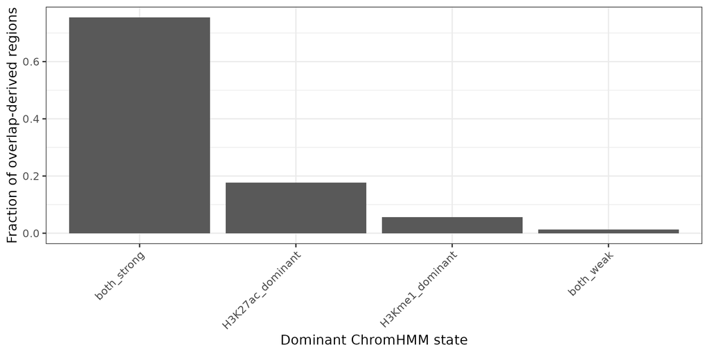

This is the point where the practical moves from **producing files** to **testing a biological hypothesis**.

The graph above is not just a summary of which bar is tallest. It asks whether the candidate regulatory regions from `Task 8` remain convincing when viewed through an independent, model-based chromatin-state framework. In this dataset, most overlap-derived regions are assigned to the `both_strong` state, while smaller fractions fall into `H3K27ac_dominant`, `H3K4me1_dominant`, or `both_weak` states. That is an encouraging result: it means that the majority of regions jointly marked by `H3K27ac` and `H3K4me1` are also placed by `ChromHMM` into the state with strongest combined signal for both marks.

This strengthens the interpretation developed across the earlier tasks. In `Task 7`, the peak sets passed basic quality-control checks. In `Task 8`, overlapping `H3K27ac` and `H3K4me1` peaks were used as a first-pass set of candidate active regulatory loci. Now, in `Task 9`, the chromatin-state model provides an additional layer of support: most of those candidate loci are assigned to a state compatible with strong signal for both marks, rather than being scattered mainly across weak or ambiguous states.

The smaller secondary classes are still biologically informative. Regions assigned to `H3K27ac_dominant` may reflect loci with stronger acetylation than methylation, whereas `H3K4me1_dominant` regions may include weaker or less active enhancer-like loci. The very small `both_weak` fraction suggests that only a minority of the overlap-derived regions are being assigned to a weak-signal state by the model. In other words, the final result is not simply “nice, one column is higher”: it is that the candidate regions identified from peak overlap are, for the most part, supported by an independent chromatin-state model.

This does **not** prove that every region is a bona fide active enhancer. The practical still uses only two histone marks on `chr21`, so the final interpretation should remain cautious. But it does give a biologically meaningful endpoint for Task 9: the workflow has narrowed `chr21` down to a set of candidate regulatory regions that are supported by read enrichment, peak overlap, nearest-gene association, and dominant assignment to a both-strong chromatin state. In the next task, we will place these same regions back onto `chr21` in a chromosome-level view so that the result can be inspected visually as well as statistically.

**NoteT9 Q1**

Which files produced by `BinarizeBam` confirm that the K562 histone ChIP-seq data were successfully converted into ChromHMM binary input?

**NoteT9 Q2**

Based on `emissions_4.txt`, which state or states look most compatible with enhancer-like chromatin, and why?

**NoteT9 Q3**

After assigning each overlap-derived region to the ChromHMM state with the **largest base-pair overlap**, do the regions fall primarily into the state labelled as `both_strong` (or otherwise enhancer-like)?

## Task 10: Karyoscape - visualising candidate regulatory states along `chr21`

By the end of Task 9, we have already built and interpreted a small chromatin-state model. The remaining question is how those assignments are arranged along the chromosome. A chromosome-level visualisation helps us see whether the candidate regions form isolated loci, local clusters, or broader domains, and it gives us a satisfying final view of how the peak-overlap regions relate to the learned `ChromHMM` segmentation.

This task has three parts:

1. prepare the segmentation and overlap-derived regions for plotting,
2. customise colours and layout for a chromosome-level figure,
3. draw and save a final `chr21` visualisation with `karyoploteR`.

We will use the `karyoploteR` package, which is designed for plotting data along a linear genome. Here we will create a two-track `chr21` view:

- the **top track** will show the overlap-derived candidate regulatory regions from `Task 8`, coloured by their **dominant ChromHMM state**;
- the **bottom track** will show the full `ChromHMM` segmentation across `chr21`.

This does not replace the summary statistics from `Task 9.6`; instead, it complements them by adding the genomic context. It also gives you a final figure that you can inspect visually and tweak by changing colours, margins, zoom settings, or optional gene labels.

We start by loading the libraries:

```r
library(karyoploteR)
library(GenomicRanges)
```

Load the ChromHMM segments and attach the chosen state labels.

```r
state_labels <- read.delim(
  "0007_states/state_labels.tsv",
  stringsAsFactors = FALSE
)

segments <- read.delim(
  "0007_states/model/K562_4_segments.bed",
  header = FALSE,
  stringsAsFactors = FALSE
)
colnames(segments) <- c("chr", "start", "end", "state_id")

segments <- merge(segments, state_labels, by = "state_id", all.x = TRUE, sort = FALSE)
segments$state_label[is.na(segments$state_label)] <- segments$state_id
```

Read the peak–state intersections and sort them by overlap size.

```r
overlap_hits <- read.delim(
  "0007_states/H3K27ac_H3K4me1_overlap_vs_ChromHMM.tsv",
  header = FALSE,
  stringsAsFactors = FALSE
)
colnames(overlap_hits) <- c(
  "peak_chr", "peak_start", "peak_end", "peak_id", "peak_score",
  "peak_strand", "peak_signal", "peak_pvalue", "peak_qvalue",
  "state_chr", "state_start", "state_end", "state_id", "overlap_bp"
)

overlap_hits <- overlap_hits[order(overlap_hits$peak_id, -overlap_hits$overlap_bp), ]
```

Assign one dominant state per region and define plotting colours.

```r
peak_state <- overlap_hits[!duplicated(overlap_hits$peak_id),
                           c("peak_chr", "peak_start", "peak_end", "peak_id", "state_id", "overlap_bp")]

peak_state <- merge(peak_state, state_labels, by = "state_id", all.x = TRUE, sort = FALSE)
peak_state$state_label[is.na(peak_state$state_label)] <- peak_state$state_id

# Edit these colours if you want to try a different palette
state_cols <- c(
  both_strong = "#D73027",
  H3K27ac_dominant = "#FC8D59",
  H3K4me1_dominant = "#4575B4",
  both_weak = "#BDBDBD"
)

legend_labels <- c(
  "both strong",
  "H3K27ac dom.",
  "H3K4me1 dom.",
  "both weak"
)

segment_cols <- state_cols[segments$state_label]
segment_cols[is.na(segment_cols)] <- "#BDBDBD"
segment_cols <- adjustcolor(segment_cols, alpha.f = 0.45)
segment_cols[segments$state_label == "both_weak"] <- "#E6E6E6"

peak_cols <- adjustcolor(state_cols[peak_state$state_label], alpha.f = 0.90)
peak_cols[is.na(peak_cols)] <- adjustcolor("#969696", alpha.f = 0.90)

# For the top track, use the midpoint of each overlap-derived region so the
# markers remain visible at chromosome scale.
peak_mid <- floor((peak_state$peak_start + peak_state$peak_end) / 2)
```

Tune margins and panel sizes for the chromosome plot, and add placeholder for gene labels:

```r
plot.params <- getDefaultPlotParams(plot.type = 2)
plot.params$leftmargin <- 0.10
plot.params$rightmargin <- 0.20
plot.params$topmargin <- 35
plot.params$bottommargin <- 28
plot.params$data1height <- 85
plot.params$data2height <- 125
plot.params$ideogramheight <- 18

gene_gr <- GRanges()
```

**Optional zoom**: edit and use this code if you want to inspect a smaller part of chr21

```r
zoom_region <- GRanges("chr21", IRanges(34000000, 37000000))
```

**Optional gene labels**: edit and use this code if you want to highlight one or more loci on `chr21`

```r
gene_gr <- GRanges(
  seqnames = c("chr21"),
  ranges = IRanges(
    start = c(34787801),
    end = c(36004667)
  )
)

mcols(gene_gr)$gene <- c("RUNX1")
```

Draw the `chr21` plot, add the two tracks, and save the image.

```r
png("0007_states/Task10_karyoploteR_chr21_states.png", width = 2100, height = 900, res = 180)

kp <- plotKaryotype(
  genome = "hg38",
  chromosomes = "chr21",
  plot.type = 2,
  plot.params = plot.params
  # zoom = zoom_region
)

kpDataBackground(kp, data.panel = 1, color = "#FAFAFA")
kpDataBackground(kp, data.panel = 2, color = "#FAFAFA")
kpAddBaseNumbers(kp, tick.dist = 5000000, add.units = TRUE, cex = 0.8)

# Top panel: plot overlap-derived regions as thicker vertical markers so they
# remain visible at whole-chromosome scale.
kpSegments(
  kp,
  chr = peak_state$peak_chr,
  x0 = peak_mid,
  x1 = peak_mid,
  y0 = 0.18,
  y1 = 0.82,
  col = peak_cols,
  lwd = 2.2,
  data.panel = 1
)

# Bottom panel: full ChromHMM segmentation along chr21
# For visualisation only, enforce a minimum display width for non-both_weak states
# so they remain visible at whole-chromosome scale.
chr21_length <- 46709983L
min_state_width_bp <- 100000L

segment_plot_start <- segments$start + 1L
segment_plot_end <- segments$end
segment_mid <- floor((segment_plot_start + segment_plot_end) / 2)

is_nonweak <- segments$state_label != "both_weak"
segment_width <- segment_plot_end - segment_plot_start + 1L
needs_widening <- is_nonweak & segment_width < min_state_width_bp

segment_plot_start[needs_widening] <- pmax(
  1L,
  segment_mid[needs_widening] - floor(min_state_width_bp / 2)
)
segment_plot_end[needs_widening] <- pmin(
  chr21_length,
  segment_mid[needs_widening] + ceiling(min_state_width_bp / 2) - 1L
)

kpRect(
  kp,
  chr = segments$chr,
  x0 = segment_plot_start,
  x1 = segment_plot_end,
  y0 = 0.28,
  y1 = 0.82,
  col = segment_cols,
  border = NA,
  data.panel = 2
)

# Optional: highlight and label selected genes
if (length(gene_gr) > 0) {
  gene_mid <- start(gene_gr) + floor((end(gene_gr) - start(gene_gr)) / 2)

  # Light highlight of the gene span on the ChromHMM panel
  kpRect(
    kp,
    chr = as.character(seqnames(gene_gr)),
    x0 = start(gene_gr),
    x1 = end(gene_gr),
    y0 = 0.12,
    y1 = 0.25,
    col = adjustcolor("#800080", alpha.f = 0.5),
    lwd = 0.8,
    data.panel = 2
  )

  kpText(
    kp,
    chr = as.character(seqnames(gene_gr)),
    x = gene_mid,
    y = 0.17,
    labels = mcols(gene_gr)$gene,
    pos = 3,
    data.panel = 2
  )
}

par(xpd = NA)
usr <- par("usr")

legend(
  x = usr[2] - 0.18 * (usr[2] - usr[1]),
  y = usr[4] + 0.10 * (usr[4] - usr[3]),
  legend = legend_labels,
  fill = unname(state_cols),
  border = NA,
  bty = "n",
  cex = 0.9,
  title = "State",
  xjust = 0,
  yjust = 1
)

mtext(
  "Top: overlap-derived regions from Task 8",
  side = 3,
  line = 1.0,
  adj = 0.18,
  cex = 0.95
)

mtext(
  "Bottom: ChromHMM segmentation on chr21",
  side = 1,
  line = 1.8,
  adj = 0.18,
  cex = 0.95
)

dev.off()
```

This code reads the segmentation and overlap files created in the previous steps, assigns one dominant state per overlap-derived region, and then plots both layers along the same chromosome. The top panel answers “where are the candidate regions we carried forward from Task 8?”, while the bottom panel shows the underlying `ChromHMM` state structure across the whole of `chr21`. After you get the first version working, try changing the colour palette, margins, zoom settings, or optional `GRanges` gene labels to make the chromosome view clearer and more biologically informative. To add more genes, extend the `seqnames`, `start`, `end`, and `gene` vectors with one extra entry per gene.[^13]

The resulting figure should look like this:

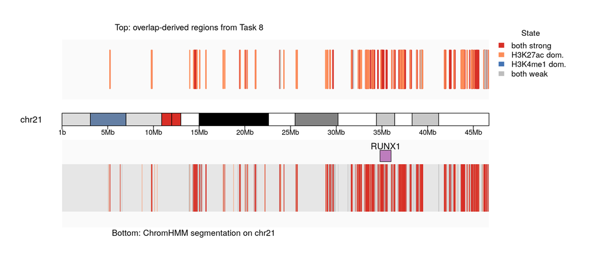

# Suggested interpretation workflow

If you finish the tasks, try to summarise the whole analysis in the following order:

1. **Metadata and design**: which experiments and controls did we analyse?
2. **Global quality**: do the samples cluster as expected?
3. **Local inspection**: do the browser tracks show convincing enrichment above Input?
4. **Technical bias**: are the GC-bias patterns or cross-correlation profiles suspicious?
5. **Biological plausibility**: do the marks concentrate in plausible regulatory categories?
6. **Peak-level interpretation**: do the called regions and reads-in-peaks summaries support successful enrichment?
7. **Peak-overlap interpretation**: which regions jointly marked by `H3K27ac` and `H3K4me1` look most like candidate active regulatory loci?
8. **Chromatin-state interpretation**: do the ChromHMM state labels support an enhancer-like / both-high interpretation of those regions, or do they instead suggest more `H3K4me1`-dominant, `H3K27ac`-dominant, mixed, or weak-signal states?

# What we are not doing today

To keep the practical focused and feasible, we are **not** including the following as core tasks:

- `FastQC` on raw reads
- read mapping with `Bowtie2` or a similar aligner
- differential peak calling between conditions
- motif discovery as a main endpoint
- training a large multi-mark genome-wide ChromHMM model

This practical starts from already prepared `BAM` and `bigWig` files, so the focus is on interpretation, quality assessment, peak calling, overlap analysis, chromatin-state modelling, and chromosome-level visualisation rather than on raw-read preprocessing.

We do, however, include a **hands-on ChromHMM step** on a reduced two-mark `chr21` example, because it gives you direct experience with binarisation, model learning, and state interpretation in a manageable classroom setting.

# Optional extension questions

**NoteBonus Q1**

Would you expect the overlap of `H3K4me1` and `H3K27ac` to be more enriched near active enhancers or near constitutively silent genomic regions?

**NoteBonus Q2**

How would you extend this practical if you also had K562 `RNA-seq` data from the same cell type?

**NoteBonus Q3**

Which additional experiment would you add to refine the interpretation of candidate enhancer-like regions: `ATAC-seq`, a transcription factor `ChIP-seq`, or `RNA-seq`? Explain your choice.

**NoteBonus Q4**

If a region is supported by `H3K27ac` + `H3K4me1` peak overlap but falls into a promoter-like ChromHMM state, how would you reconcile the two interpretations?

# Quit session

After finishing all the work on RStudio server, quit from the session by clicking on the button on the right or from the File ➔ Quit Session menu point. Then you can choose to **save the workspace**.

## References

- Barbarani, Gloria, Antonella Ronchi, Margherita Ruoppolo, et al. 2017. “Unravelling Pathways Downstream Sox6 Induction in K562 Erythroid Cells by Proteomic Analysis.” *Scientific Reports* 7 (1): 14088. https://doi.org/10.1038/s41598-017-14336-6.
- Calo, Edith, and Joanna Wysocka. 2013. “Modification of Enhancer Chromatin: What, How, and Why?” *Molecular Cell* 49 (5): 825–37. https://doi.org/10.1016/j.molcel.2013.01.038.
- Creyghton, Menno P., Albert W. Cheng, Gregory G. Welstead, et al. 2010. “Histone H3K27ac Separates Active from Poised Enhancers and Predicts Developmental State.” *Proceedings of the National Academy of Sciences of the United States of America* 107 (50): 21931–36. https://doi.org/10.1073/pnas.1016071107.
- Davis, Carrie A., Benjamin C. Hitz, Cricket A. Sloan, et al. 2018. “The Encyclopedia of DNA Elements (ENCODE): Data Portal Update.” *Nucleic Acids Research* 46 (D1): D794–D801. https://doi.org/10.1093/nar/gkx1081.
- ENCODE Project Consortium. 2012. “An Integrated Encyclopedia of DNA Elements in the Human Genome.” *Nature* 489: 57–74. https://doi.org/10.1038/nature11247.
- ENCODE Data Coordination Center. 2020. “ENCODE4 Histone ChIP-seq Data Standards and Processing Pipeline.” *ENCODE Project*. Updated July 2020. https://www.encodeproject.org/chip-seq/histone-encode4/.
- Ernst, Jason, and Manolis Kellis. 2012. “ChromHMM: Automating Chromatin-State Discovery and Characterization.” *Nature Methods* 9 (3): 215–16. https://doi.org/10.1038/nmeth.1906.
- Ernst, Jason, and Manolis Kellis. 2017. “Chromatin-State Discovery and Genome Annotation with ChromHMM.” *Nature Protocols* 12 (12): 2478–92. https://doi.org/10.1038/nprot.2017.124.
- Heintzman, Nathaniel D., Gary C. Hon, Ryan D. Hawkins, et al. 2009. “Histone Modifications at Human Enhancers Reflect Global Cell-Type-Specific Gene Expression.” *Nature* 459 (7243): 108–12. https://doi.org/10.1038/nature07829.
- Landt, Stephen G., Gad K. Marinov, Anshul Kundaje, et al. 2012. “ChIP-Seq Guidelines and Practices of the ENCODE and modENCODE Consortia.” *Genome Research* 22 (9): 1813–31. https://doi.org/10.1101/gr.136184.111.
- Li, Heng, Bob Handsaker, Alec Wysoker, et al. 2009. “The Sequence Alignment/Map Format and SAMtools.” *Bioinformatics* 25 (16): 2078–79. https://doi.org/10.1093/bioinformatics/btp352.
- Park, Peter J. 2009. “ChIP-seq: Advantages and Challenges of a Maturing Technology.” *Nature Reviews Genetics* 10 (10): 669–80. https://doi.org/10.1038/nrg2641.
- Quinlan, Aaron R., and Ira M. Hall. 2010. “BEDTools: A Flexible Suite of Utilities for Comparing Genomic Features.” *Bioinformatics* 26 (6): 841–42. https://doi.org/10.1093/bioinformatics/btq033.
- Roadmap Epigenomics Consortium, Anshul Kundaje, Wouter Meuleman, Jason Ernst, et al. 2015. “Integrative Analysis of 111 Reference Human Epigenomes.” *Nature* 518 (7539): 317–30. https://doi.org/10.1038/nature14248.
- Xu, Jinrui, Michelle M. Kudron, Alec Victorsen, Jiahao Gao, Haneen N. Ammouri, Fabio C. P. Navarro, Louis Gevirtzman, Robert H. Waterston, Kevin P. White, Valerie Reinke, and Mark Gerstein. 2021. “To Mock or Not: A Comprehensive Comparison of Mock IP and DNA Input for ChIP-Seq.” *Nucleic Acids Research* 49 (3): e17. https://doi.org/10.1093/nar/gkaa1155.
- Zhang, Yong, Tao Liu, Clifford A. Meyer, et al. 2008. “Model-Based Analysis of ChIP-Seq (MACS).” *Genome Biology* 9 (9): R137. https://doi.org/10.1186/gb-2008-9-9-r137.

## Footnotes

[^1]: Restricting the analysis to `chr21` is a pedagogical shortcut to keep runtime manageable in class, since chr21 is the smallest human autosome. For real histone ChIP-seq studies, quality control, peak calling, and downstream interpretation should normally be assessed genome-wide.
[^2]: We use the `BAM` file with **Output = `alignments`** rather than **`unfiltered alignments`** because `alignments` is the filtered, analysis-ready version of the mapped reads. Using the filtered `BAM` makes the downstream practical more reproducible and avoids giving different students files that still contain reads usually removed before analysis.
[^3]: We use the `bigWig` file with **Output = `fold change over control`** rather than **`signal p-value`** because in this practical the `bigWig` files are mainly used as genome-browser tracks. `Fold change over control` is easier to interpret visually as enrichment over the matched input, whereas `signal p-value` reflects statistical confidence rather than signal magnitude. The input sample is left without a `bigWig` entry in the manifest on purpose, so that all students use the same two histone browser tracks and inspect the input directly from its `BAM` file.
[^4]: If downloading and subsetting the original files becomes too slow or cumbersome during the practical, you can copy the prepared backup files from the shared course folder instead:

    ```bash
    # copy prepared chr21-restricted BAM files
    tail -n +2 0000_metadata/encode_k562_manifest.tsv | cut -f1 | while read s; do
      cp -n "/shared/OMICS/practical_09/0001_bam/${s}.chr21.bam" 0001_bam/
    done
    ```

    ```bash
    # copy the selected histone bigWig files listed in the manifest
    tail -n +2 0000_metadata/encode_k562_manifest.tsv | cut -f10 | grep -v '^$' | while read f; do
      cp -n "/shared/OMICS/practical_09/0002_bigwig/${f}" 0002_bigwig/
    done
    ```

    For a given sample, the CPM of a bin is calculated as:

    `CPM = (raw count in the bin / total counts in the sample) × 10^6`

    So the y-axis is really:

    `log10(CPM + 1) = log10((k / N) × 10^6 + 1)`

    where `N` is the total number of counted fragments in that sample.

    For example, if the sample has about `124,000` total counts, then:
    - `k = 0` gives `CPM = 0`, so `log10(0 + 1) = 0`
    - `k = 1` gives about `8.1 CPM`, so `log10(9.1) ≈ 0.96`
    - `k = 2` gives about `16.1 CPM`, so `log10(17.1) ≈ 1.23`
    - `k = 3` gives about `24.2 CPM`, so `log10(25.2) ≈ 1.40`

    This is why the first non-zero row appears much higher than `0.301`: the plot uses `log10(CPM + 1)`, not `log10(raw count + 1)`. In other words, the visible horizontal bands correspond to bins with the same **raw integer count**, after library-size normalisation.
[^8]: This task builds the annotation locally with Bioconductor instead of relying on pre-made shared `BED` files. Students who do not have access to `/shared/OMICS` can still reproduce it from the package documentation and export their own `BED` files. Useful links: `TxDb.Hsapiens.UCSC.hg38.knownGene` https://bioconductor.org/packages/release/data/annotation/html/TxDb.Hsapiens.UCSC.hg38.knownGene.html; `GenomicFeatures` vignette https://bioconductor.posit.co/packages/3.23/bioc/vignettes/GenomicFeatures/inst/doc/GenomicFeatures.html; `rtracklayer` export documentation https://rdrr.io/bioc/rtracklayer/man/export.html; `AnnotationHub` how-to pages https://bioconductor.posit.co/packages/3.23/bioc/vignettes/AnnotationHub/inst/doc/AnnotationHub-HOWTO.html.
[^9]: The original `MACS` paper describes the method family behind later `MACS2` releases, and it remains the standard citation for this peak-calling framework.
[^10]: FRiP stands for **fraction of reads in peaks**. In production analyses, it is usually computed after consistent filtering choices and on complete peak sets; here we use a simplified classroom approximation based on the staged files (Landt 2012).
[^11]: The Java flag `-Djava.awt.headless=true` tells Java to run without trying to connect to a graphical display server. This is useful on remote servers or browser-based sessions, where `ChromHMM` can otherwise fail while attempting to create graphics or open browser output. The `ChromHMM` manual documents `-noimage` and `-nobrowser` as options to suppress image and browser-related output, and the maintainer’s issue tracker explicitly notes `-Djava.awt.headless=true` as a practical workaround for headless environments (Ernst and Kellis 2012; ChromHMM manual; ChromHMM GitHub issue #1).
[^12]: The Java flag `-Djava.awt.headless=true` tells Java to run without trying to connect to a graphical display server. This is useful on remote servers or browser-based sessions, where `ChromHMM` can otherwise fail while attempting to create graphics or open browser output. The `ChromHMM` manual documents `-noimage` and `-nobrowser` as options to suppress image and browser-related output, and the maintainer’s issue tracker explicitly notes `-Djava.awt.headless=true` as a practical workaround for headless environments (Ernst and Kellis 2012; ChromHMM manual; ChromHMM GitHub issue #1).
[^13]: For example, with two biologically relevant chr21 genes in this context:

    ```r
    gene_gr <- GRanges(
      seqnames = c("chr21", "chr21"),
      ranges = IRanges(
        start = c(34787801, 38380027),
        end = c(36004667, 38584945)
      )
    )

    mcols(gene_gr)$gene <- c("RUNX1", "ERG")
    ```